# Final Project in Time Series Analysis: forecasting Google trends with VAR AND ARIMA models

Lin Xinyang

2023-05-27

## 1. Loading Packages

Firstly, let’s load packages we need for our analysis.

```r
options(repos = c(CRAN = "https://cloud.r-project.org"))
install.packages("gtrendsR")
install.packages("dplyr")
```

[output not shown]

```r
install.packages("lmtest")
install.packages("tidyverse")
install.packages("xts")
install.packages("tseries")
install.packages("urca")
install.packages("fUnitRoots")
install.packages("knitr")
install.packages("forecast")
install.packages("quantmod")
install.packages("vars")
install.packages("formattable")
```

```r
install.packages("ggplot2")
source(file="D://Desktop//function_plot_ACF_PACF_resids.R")
source(file="D://Desktop//testdf.R")

library(gtrendsR)
library(dplyr)
library(lmtest)
library(tidyverse)
library(xts)
library(tseries)
library(urca)
library(fUnitRoots)
library(knitr)
library(forecast)
library(quantmod)
library(vars)
library(formattable)
library(ggplot2)
```

## 2. Import Data We Need

We need to import data from Google Search Engine First

```r
set.seed(123)
```

```r
rock_and_roll <- gtrends(keyword =c("rock and roll"),
                         gprop = "web",
                         time= "2004-01-01 2016-06-01")
```

We need to extract data from the column called “hits”

```r
rock_and_roll <- rock_and_roll$interest_over_time[,1:2]
rock_and_roll
```

| date | hits |
| --- | --- |
| 2004-01-01 | 87 |
| 2004-02-01 | 75 |
| 2004-03-01 | 100 |
| 2004-04-01 | 88 |
| 2004-05-01 | 78 |
| 2004-06-01 | 80 |
| 2004-07-01 | 73 |
| 2004-08-01 | 76 |
| 2004-09-01 | 79 |
| 2004-10-01 | 78 |

[output cut: 140 more lines]

```r
class(rock_and_roll)
```

```
## [1] "data.frame"
```

Then we perform the same steps to our second phrase “heavy metal”

```r
heavy_metal <- gtrends(keyword = c("heavy metal"),
                       gprop = "web",
                       time= "2004-01-01 2016-06-01")

heavy_metal<-heavy_metal$interest_over_time[,1:2]
```

Then we need to combine two data sets in one data frame

```r
rock_and_roll_heavy_metal <- cbind(rock_and_roll,heavy_metal$hits)
colnames(rock_and_roll_heavy_metal) <- c("date","rock_and_roll","heavy_metal")
rock_and_roll_heavy_metal
```

| date | rock_and_roll | heavy_metal |
| --- | --- | --- |
| 2004-01-01 | 87 | 100 |
| 2004-02-01 | 75 | 96 |
| 2004-03-01 | 100 | 99 |
| 2004-04-01 | 88 | 98 |
| 2004-05-01 | 78 | 95 |
| 2004-06-01 | 80 | 90 |
| 2004-07-01 | 73 | 91 |
| 2004-08-01 | 76 | 95 |
| 2004-09-01 | 79 | 86 |
| 2004-10-01 | 78 | 86 |

[output cut: 140 more lines]

In the next step, we need coerce “rock_and_roll_heavy_metal” into xts

```r
options(xts_check_TZ = FALSE)
rock_and_roll_heavy_metal <- xts(rock_and_roll_heavy_metal[,-1],rock_and_roll_heavy_metal$date)
rock_and_roll_heavy_metal
```

```
##            rock_and_roll heavy_metal
## 2004-01-01            87         100
## 2004-02-01            75          96
## 2004-03-01           100          99
## 2004-04-01            88          98
## 2004-05-01            78          95
## 2004-06-01            80          90
## 2004-07-01            73          91
## 2004-08-01            76          95
## 2004-09-01            79          86
## 2004-10-01            78          86
##        ...
## 2015-09-01            53          33
## 2015-10-01            55          32
## 2015-11-01            45          33
## 2015-12-01            49          33
## 2016-01-01            48          30
## 2016-02-01            48          32
## 2016-03-01            44          28
## 2016-04-01            54          30
## 2016-05-01            53          32
## 2016-06-01            47          30
```

```r
class(rock_and_roll_heavy_metal)
```

```
## [1] "xts" "zoo"
```

## 3.Build a VAR model

1. **First thing first,** let’s check their stationarity , and if they are both non-stationary, we also need to examine whether they are integrated of the same order.

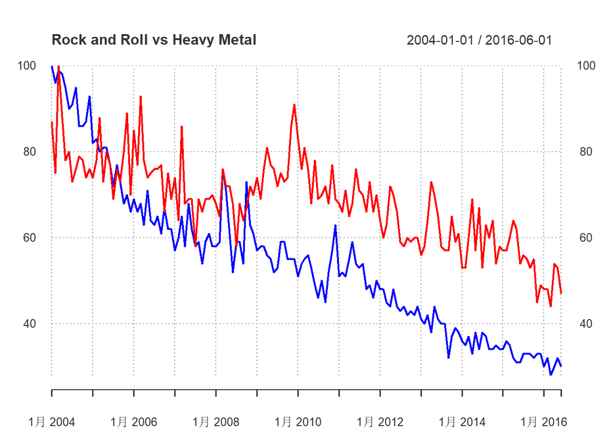

```r
plot(rock_and_roll_heavy_metal[,1:2],
     col=c("red","blue"),
     major.ticks="years",
     grid.ticks.on= "years",
     grid.ticks.lty=3,
     main= "Rock and Roll vs Heavy Metal")
```

Judging from the graph, it is obvious that they don’t look stationary. But we also need to perform ADF test to further confirm.

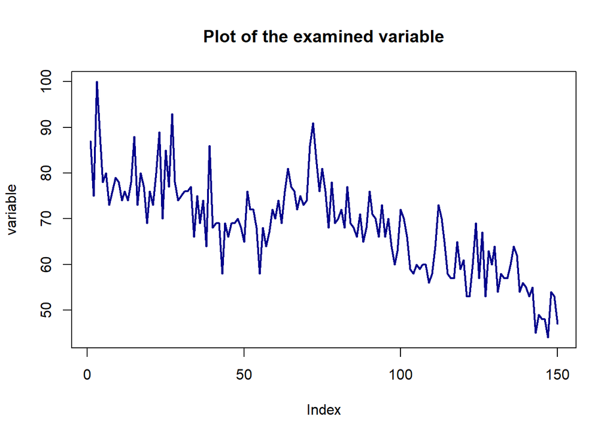

| augmentations | adf | p_adf | bgodfrey | p_bg |
| --- | --- | --- | --- | --- |
| 0 | -4.6047324 | 0.0100000 | 1.601728e+01 | 6.276714e-05 |
| 1 | -2.3853542 | 0.1709885 | 1.198522e-01 | 7.291948e-01 |
| 2 | -2.4955737 | 0.1301046 | 1.108546e-01 | 7.391732e-01 |
| 3 | -2.2115304 | 0.2354652 | 6.035269e-02 | 8.059394e-01 |
| 4 | -1.2746710 | 0.5829757 | 1.836652e-01 | 6.682422e-01 |
| 5 | -0.9602488 | 0.6996048 | 7.954641e-04 | 9.774995e-01 |

```r
testdf(rock_and_roll_heavy_metal$rock_and_roll,max.augmentations =5)
```

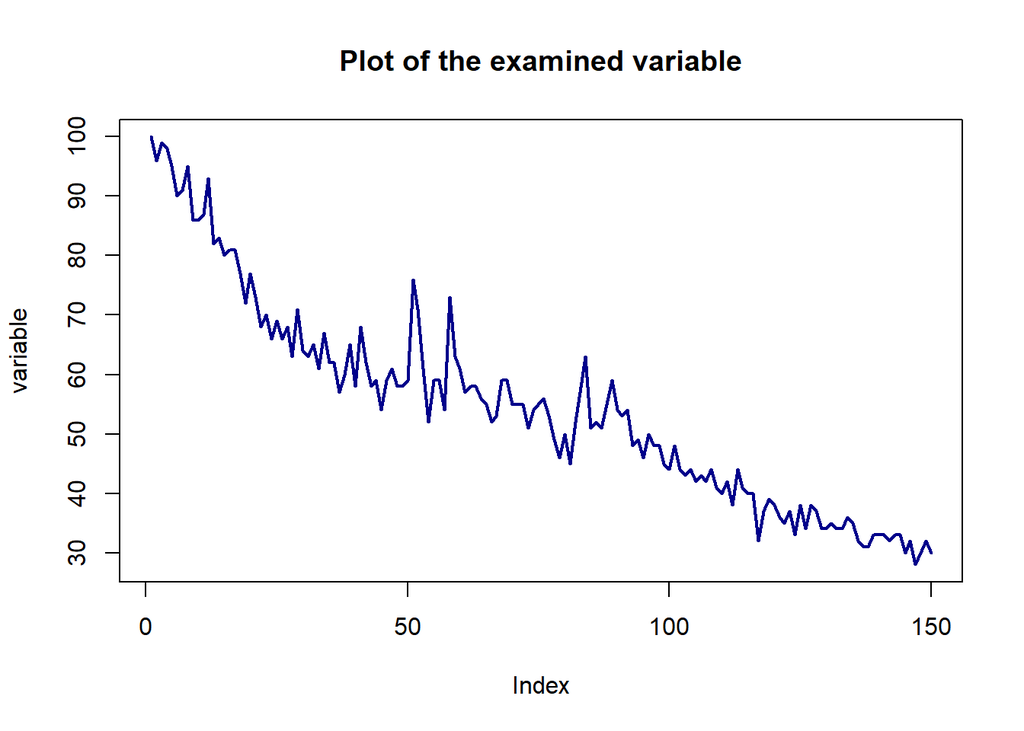

| augmentations | adf | p_adf | bgodfrey | p_bg |
| --- | --- | --- | --- | --- |
| 0 | -2.367901 | 0.17746259 | 17.56111263 | 2.782201e-05 |
| 1 | -2.090860 | 0.28022554 | 0.71144159 | 3.989657e-01 |
| 2 | -2.279728 | 0.21016875 | 0.36990234 | 5.430575e-01 |
| 3 | -2.478616 | 0.13639485 | 0.43856114 | 5.078178e-01 |
| 4 | -2.669799 | 0.08498942 | 0.05195995 | 8.196873e-01 |
| 5 | -2.497976 | 0.12921367 | 0.04806910 | 8.264579e-01 |

```r
testdf(rock_and_roll_heavy_metal$heavy_metal,max.augmentations = 5)
```

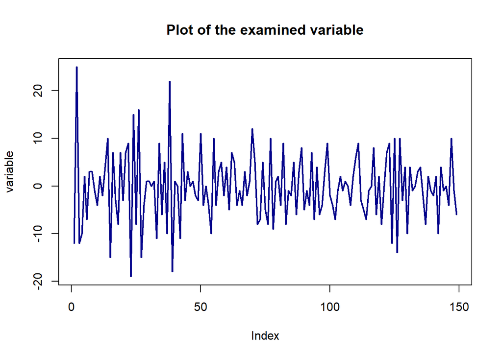

| augmentations | adf | p_adf | bgodfrey | p_bg |
| --- | --- | --- | --- | --- |
| 0 | -21.598021 | 0.01 | 0.398821321 | 0.5276986 |
| 1 | -12.458184 | 0.01 | 0.114253366 | 0.7353527 |
| 2 | -10.015488 | 0.01 | 0.220262050 | 0.6388403 |
| 3 | -9.948728 | 0.01 | 0.302018358 | 0.5826198 |
| 4 | -8.747865 | 0.01 | 0.004370936 | 0.9472878 |
| 5 | -7.138886 | 0.01 | 0.006141591 | 0.9375351 |

```r
rock_and_roll_heavy_metal$rr_d <- diff(rock_and_roll_heavy_metal$rock_and_roll)
rock_and_roll_heavy_metal$hm_d <- diff(rock_and_roll_heavy_metal$heavy_metal)
testdf(rock_and_roll_heavy_metal$rr_d,max.augmentations = 5)
```

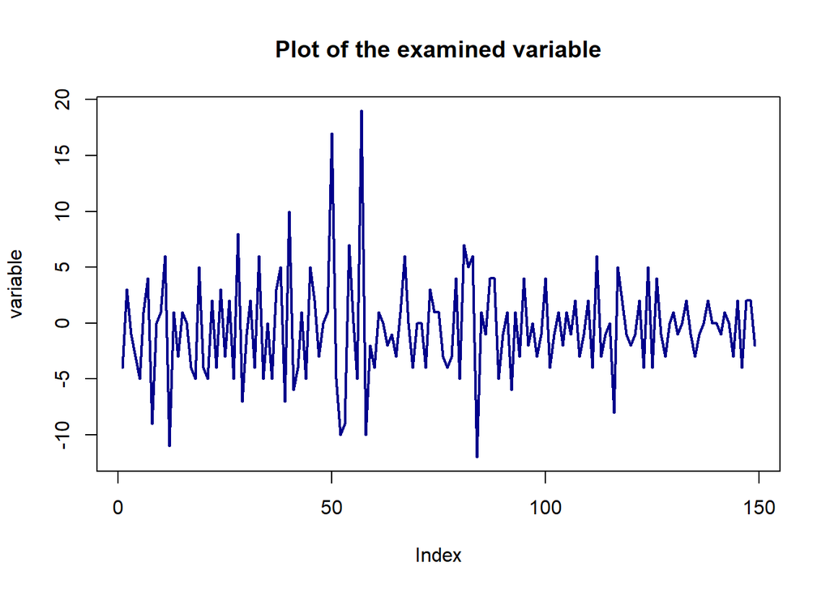

| augmentations | adf | p_adf | bgodfrey | p_bg |
| --- | --- | --- | --- | --- |
| 0 | -17.664467 | 0.01 | 0.69789493 | 0.4034919 |
| 1 | -12.086469 | 0.01 | 0.28419751 | 0.5939631 |
| 2 | -10.587012 | 0.01 | 0.33394000 | 0.5633482 |
| 3 | -9.807992 | 0.01 | 0.04271040 | 0.8362715 |
| 4 | -7.971560 | 0.01 | 0.02998320 | 0.8625284 |
| 5 | -8.121215 | 0.01 | 0.03420409 | 0.8532734 |

```r
testdf(rock_and_roll_heavy_metal$hm_d,max.augmentations = 5)
```

After the first differencing, p-values of both are smaller than 0.05, so the null hypothesis of ADF test assuming the existence of a unit root can be rejected. This suggests that both are integrated of the order 1; also BG test suggests that the error terms of both data sets are stationary

2. **Let’s figure out their linear combination**

```r
linr_comb <- lm(rock_and_roll ~ heavy_metal, data=rock_and_roll_heavy_metal)
summary(linr_comb)
```

```
##
## Call:
## lm(formula = rock_and_roll ~ heavy_metal, data = rock_and_roll_heavy_metal)
##
## Residuals:
##     Min      1Q  Median      3Q     Max
## -14.036  -4.076  -1.268   4.265  22.409
##
## Coefficients:
##             Estimate Std. Error t value Pr(>|t|)
## (Intercept) 44.70203    1.82774   24.46   <2e-16 ***
## heavy_metal  0.43435    0.03184   13.64   <2e-16 ***
## ---
## Signif. codes:  0 '***' 0.001 '**' 0.01 '*' 0.05 '.' 0.1 ' ' 1
##
## Residual standard error: 6.781 on 148 degrees of freedom
## Multiple R-squared:  0.5571, Adjusted R-squared:  0.5541
## F-statistic: 186.1 on 1 and 148 DF,  p-value: < 2.2e-16
```

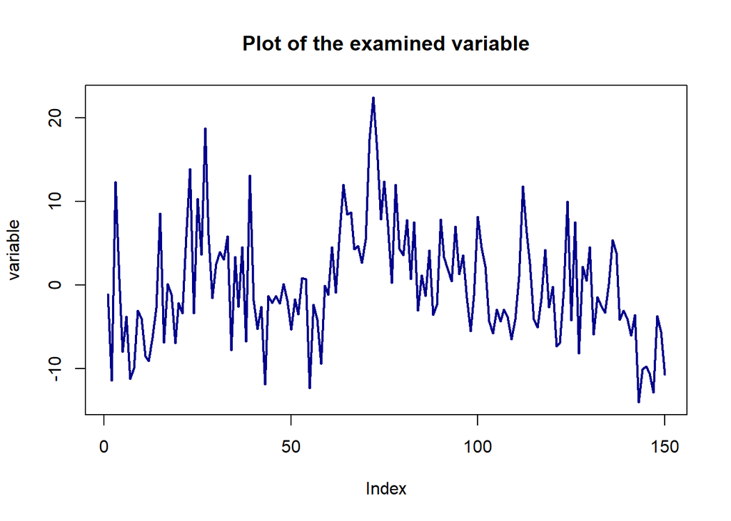

| augmentations | adf | p_adf | bgodfrey | p_bg |
| --- | --- | --- | --- | --- |
| 0 | -7.594882 | 0.01000000 | 2.519748603 | 0.1124285 |
| 1 | -4.685575 | 0.01000000 | 0.034828103 | 0.8519563 |
| 2 | -3.941640 | 0.01000000 | 0.003581339 | 0.9522796 |
| 3 | -3.375154 | 0.01533093 | 0.020582828 | 0.8859212 |

```r
testdf(variable = residuals(linr_comb),max.augmentations = 3)
```

ADF test with 0 lag rejects the null hypothesis of non-staionarity. Therefore its error term is stationary. In conclusion, “rock and roll” and “heavy metal” can be co-integrated .

3. **Let’s perform Granger causality test to further confirm their cointegration.**

```r
grangertest(  heavy_metal~rock_and_roll,
              data=rock_and_roll_heavy_metal,
              order=4 )
```

|  | Res.Df | Df | F | Pr(>F) |
| --- | --- | --- | --- | --- |
| 1 | 137 | NA | NA | NA |
| 2 | 141 | -4 | 2.39934 | 0.05307091 |

```r
grangertest(  rock_and_roll~heavy_metal,
              data=rock_and_roll_heavy_metal,
              order=2 )
```

|  | Res.Df | Df | F | Pr(>F) |
| --- | --- | --- | --- | --- |
| 1 | 143 | NA | NA | NA |
| 2 | 145 | -2 | 7.498893 | 0.0007997979 |

```r
grangertest(  rock_and_roll~heavy_metal,
              data=rock_and_roll_heavy_metal,
              order=3 )
```

|  | Res.Df | Df | F | Pr(>F) |
| --- | --- | --- | --- | --- |
| 1 | 140 | NA | NA | NA |
| 2 | 143 | -3 | 4.092289 | 0.008064225 |

```r
grangertest(  rock_and_roll~heavy_metal,
              data=rock_and_roll_heavy_metal,
              order=4 )
```

|  | Res.Df | Df | F | Pr(>F) |
| --- | --- | --- | --- | --- |
| 1 | 137 | NA | NA | NA |
| 2 | 141 | -4 | 3.11636 | 0.01722765 |

Let’s remove the third and fourth columns about the data of the first differencing.

```r
rock_and_roll_heavy_metal<-rock_and_roll_heavy_metal[,-c(3,4)]
rock_and_roll_heavy_metal
```

```
##            rock_and_roll heavy_metal
## 2004-01-01            87         100
## 2004-02-01            75          96
## 2004-03-01           100          99
## 2004-04-01            88          98
## 2004-05-01            78          95
## 2004-06-01            80          90
## 2004-07-01            73          91
## 2004-08-01            76          95
## 2004-09-01            79          86
## 2004-10-01            78          86
##        ...
## 2015-09-01            53          33
## 2015-10-01            55          32
## 2015-11-01            45          33
## 2015-12-01            49          33
## 2016-01-01            48          30
## 2016-02-01            48          32
## 2016-03-01            44          28
## 2016-04-01            54          30
## 2016-05-01            53          32
## 2016-06-01            47          30
```

4. **Let’s select a suitable VAR model for both variables.**

```r
var_selection <- VARselect(y=rock_and_roll_heavy_metal,lag.max=10)
var_selection
```

```
## $selection
## AIC(n)  HQ(n)  SC(n) FPE(n)
##      5      2      2      5
##
## $criteria
##                 1          2          3          4          5          6
## AIC(n)   6.573177   6.334308   6.334984   6.297955   6.277081   6.307900
## HQ(n)    6.624408   6.419693   6.454523   6.451649   6.464929   6.529902
## SC(n)    6.699247   6.544425   6.629148   6.676166   6.739339   6.854205
## FPE(n) 715.648973 563.613417 564.054283 543.652320 532.578402 549.480442
##                 7          8          9         10
## AIC(n)   6.310777   6.364337   6.411680   6.404764
## HQ(n)    6.566933   6.654647   6.736144   6.763383
## SC(n)    6.941129   7.078736   7.210126   7.287257
## FPE(n) 551.382202 582.160158 610.971259 607.484140
```

Information criteria AIC,FPE suggest 5 lags while HQ and SC prefers 2 lags.

```r
var_5 <- VAR(y=rock_and_roll_heavy_metal,p=5)
summary(var_5)
```

```
##
## VAR Estimation Results:
## =========================
## Endogenous variables: rock_and_roll, heavy_metal
## Deterministic variables: const
## Sample size: 145
## Log Likelihood: -842.698
## Roots of the characteristic polynomial:
## 0.9818 0.8737 0.7613 0.7613 0.7088 0.7088  0.66  0.66 0.4607 0.4607
## Call:
## VAR(y = rock_and_roll_heavy_metal, p = 5)
##
##
## Estimation results for equation rock_and_roll:
## ==============================================
## rock_and_roll = rock_and_roll.l1 + heavy_metal.l1 + rock_and_roll.l2 + heavy_metal.l2 + rock_and_roll.l3 + heavy_metal.l3 + rock_and_roll.l4 + heavy_metal.l4 + rock_and_roll.l5 + heavy_metal.l5 + const
##
##                  Estimate Std. Error t value Pr(>|t|)
## rock_and_roll.l1  0.33384    0.08426   3.962 0.000120 ***
## heavy_metal.l1    0.19008    0.12092   1.572 0.118315
## rock_and_roll.l2  0.31456    0.08847   3.556 0.000522 ***
## heavy_metal.l2   -0.20454    0.13281  -1.540 0.125916
## rock_and_roll.l3 -0.09273    0.08995  -1.031 0.304438
## heavy_metal.l3    0.16229    0.13364   1.214 0.226732
## rock_and_roll.l4  0.05480    0.08617   0.636 0.525872
## heavy_metal.l4   -0.15989    0.13119  -1.219 0.225076
## rock_and_roll.l5  0.14964    0.08312   1.800 0.074061 .
## heavy_metal.l5    0.12030    0.11830   1.017 0.311050
## const            10.02873    4.66301   2.151 0.033294 *
## ---
## Signif. codes:  0 '***' 0.001 '**' 0.01 '*' 0.05 '.' 0.1 ' ' 1
##
##
## Residual standard error: 5.499 on 134 degrees of freedom
## Multiple R-Squared: 0.699,   Adjusted R-squared: 0.6765
## F-statistic: 31.12 on 10 and 134 DF,  p-value: < 2.2e-16
##
##
## Estimation results for equation heavy_metal:
## ============================================
```

[output cut: 18 more lines]

```
## Residual standard error: 3.861 on 134 degrees of freedom
## Multiple R-Squared: 0.9443,  Adjusted R-squared: 0.9401
## F-statistic:   227 on 10 and 134 DF,  p-value: < 2.2e-16
##
##
##
## Covariance matrix of residuals:
##               rock_and_roll heavy_metal
## rock_and_roll        30.236       1.555
## heavy_metal           1.555      14.907
##
## Correlation matrix of residuals:
##               rock_and_roll heavy_metal
## rock_and_roll       1.00000     0.07324
## heavy_metal         0.07324     1.00000
```

Let’s try other models.

```r
var_2 <-VAR(y=rock_and_roll_heavy_metal,p=2)
summary(var_2)
```

```
##
## VAR Estimation Results:
## =========================
## Endogenous variables: rock_and_roll, heavy_metal
## Deterministic variables: const
## Sample size: 148
## Log Likelihood: -883.1
## Roots of the characteristic polynomial:
## 0.9736 0.723 0.4145 0.4145
## Call:
## VAR(y = rock_and_roll_heavy_metal, p = 2)
##
##
## Estimation results for equation rock_and_roll:
## ==============================================
## rock_and_roll = rock_and_roll.l1 + heavy_metal.l1 + rock_and_roll.l2 + heavy_metal.l2 + const
##
##                  Estimate Std. Error t value Pr(>|t|)
## rock_and_roll.l1  0.28793    0.07910   3.640 0.000380 ***
## heavy_metal.l1    0.25189    0.11069   2.276 0.024352 *
## rock_and_roll.l2  0.35162    0.07893   4.455 1.68e-05 ***
## heavy_metal.l2   -0.08805    0.11008  -0.800 0.425107
## const            15.51563    4.13299   3.754 0.000252 ***
## ---
## Signif. codes:  0 '***' 0.001 '**' 0.01 '*' 0.05 '.' 0.1 ' ' 1
##
##
## Residual standard error: 5.815 on 143 degrees of freedom
## Multiple R-Squared: 0.6771,  Adjusted R-squared: 0.668
## F-statistic: 74.96 on 4 and 143 DF,  p-value: < 2.2e-16
##
##
## Estimation results for equation heavy_metal:
## ============================================
## heavy_metal = rock_and_roll.l1 + heavy_metal.l1 + rock_and_roll.l2 + heavy_metal.l2 + const
##
##                  Estimate Std. Error t value Pr(>|t|)
## rock_and_roll.l1 -0.04920    0.05581  -0.881   0.3796
## heavy_metal.l1    0.61264    0.07810   7.844 9.23e-13 ***
## rock_and_roll.l2  0.12715    0.05569   2.283   0.0239 *
## heavy_metal.l2    0.31205    0.07768   4.017 9.47e-05 ***
## const            -1.84749    2.91626  -0.634   0.5274
## ---
## Signif. codes:  0 '***' 0.001 '**' 0.01 '*' 0.05 '.' 0.1 ' ' 1
##
##
## Residual standard error: 4.103 on 143 degrees of freedom
## Multiple R-Squared: 0.9421,  Adjusted R-squared: 0.9405
## F-statistic: 581.4 on 4 and 143 DF,  p-value: < 2.2e-16
##
##
##
## Covariance matrix of residuals:
##               rock_and_roll heavy_metal
## rock_and_roll        33.811       3.137
## heavy_metal           3.137      16.834
##
## Correlation matrix of residuals:
##               rock_and_roll heavy_metal
## rock_and_roll        1.0000      0.1315
## heavy_metal          0.1315      1.0000
```

```r
var_6 <-VAR(y=rock_and_roll_heavy_metal,p=6)
summary(var_6)
```

```
##
## VAR Estimation Results:
## =========================
## Endogenous variables: rock_and_roll, heavy_metal
## Deterministic variables: const
## Sample size: 144
## Log Likelihood: -835.347
## Roots of the characteristic polynomial:
## 0.9832 0.9131 0.7522 0.7522 0.7304 0.7304 0.6433 0.6433 0.6252 0.6252 0.546 0.546
## Call:
## VAR(y = rock_and_roll_heavy_metal, p = 6)
##
##
## Estimation results for equation rock_and_roll:
## ==============================================
## rock_and_roll = rock_and_roll.l1 + heavy_metal.l1 + rock_and_roll.l2 + heavy_metal.l2 + rock_and_roll.l3 + heavy_metal.l3 + rock_and_roll.l4 + heavy_metal.l4 + rock_and_roll.l5 + heavy_metal.l5 + rock_and_roll.l6 + heavy_metal.l6 + const
##
##                  Estimate Std. Error t value Pr(>|t|)
## rock_and_roll.l1  0.30804    0.08732   3.528 0.000578 ***
## heavy_metal.l1    0.17946    0.12381   1.450 0.149575
## rock_and_roll.l2  0.31112    0.08953   3.475 0.000693 ***
## heavy_metal.l2   -0.19684    0.13582  -1.449 0.149636
## rock_and_roll.l3 -0.06987    0.09476  -0.737 0.462246
## heavy_metal.l3    0.18520    0.13524   1.369 0.173205
## rock_and_roll.l4  0.01054    0.09257   0.114 0.909496
## heavy_metal.l4   -0.19560    0.13491  -1.450 0.149470
## rock_and_roll.l5  0.11633    0.08672   1.341 0.182096
## heavy_metal.l5    0.15007    0.13410   1.119 0.265147
## rock_and_roll.l6  0.12001    0.08445   1.421 0.157663
## heavy_metal.l6   -0.02567    0.12111  -0.212 0.832497
## const             8.15065    4.85949   1.677 0.095876 .
## ---
## Signif. codes:  0 '***' 0.001 '**' 0.01 '*' 0.05 '.' 0.1 ' ' 1
##
##
## Residual standard error: 5.514 on 131 degrees of freedom
## Multiple R-Squared: 0.7008,  Adjusted R-squared: 0.6734
## F-statistic: 25.57 on 12 and 131 DF,  p-value: < 2.2e-16
##
##
```

[output cut: 22 more lines]

```
## Residual standard error: 3.871 on 131 degrees of freedom
## Multiple R-Squared: 0.9431,  Adjusted R-squared: 0.9378
## F-statistic: 180.8 on 12 and 131 DF,  p-value: < 2.2e-16
##
##
##
## Covariance matrix of residuals:
##               rock_and_roll heavy_metal
## rock_and_roll        30.407       1.673
## heavy_metal           1.673      14.984
##
## Correlation matrix of residuals:
##               rock_and_roll heavy_metal
## rock_and_roll       1.00000     0.07837
## heavy_metal         0.07837     1.00000
```

```r
var_7 <-VAR (y= rock_and_roll_heavy_metal,p=7)
summary (var_7)
```

```
##
## VAR Estimation Results:
## =========================
## Endogenous variables: rock_and_roll, heavy_metal
## Deterministic variables: const
## Sample size: 143
## Log Likelihood: -825.235
## Roots of the characteristic polynomial:
## 0.9842 0.8936 0.8095 0.8095 0.806 0.806 0.777 0.7539 0.7539 0.7204 0.7204 0.6365 0.6365 0.2922
## Call:
## VAR(y = rock_and_roll_heavy_metal, p = 7)
##
##
## Estimation results for equation rock_and_roll:
## ==============================================
## rock_and_roll = rock_and_roll.l1 + heavy_metal.l1 + rock_and_roll.l2 + heavy_metal.l2 + rock_and_roll.l3 + heavy_metal.l3 + rock_and_roll.l4 + heavy_metal.l4 + rock_and_roll.l5 + heavy_metal.l5 + rock_and_roll.l6 + heavy_metal.l6 + rock_and_roll.l7 + heavy_metal.l7 + const
##
##                   Estimate Std. Error t value Pr(>|t|)
## rock_and_roll.l1  0.310207   0.088371   3.510 0.000619 ***
## heavy_metal.l1    0.169035   0.125541   1.346 0.180538
## rock_and_roll.l2  0.297883   0.092094   3.235 0.001550 **
## heavy_metal.l2   -0.198190   0.137639  -1.440 0.152331
## rock_and_roll.l3 -0.060918   0.096284  -0.633 0.528067
## heavy_metal.l3    0.211091   0.138310   1.526 0.129424
## rock_and_roll.l4  0.040149   0.097617   0.411 0.681548
## heavy_metal.l4   -0.210675   0.137054  -1.537 0.126721
## rock_and_roll.l5  0.101877   0.093048   1.095 0.275622
## heavy_metal.l5    0.159218   0.138370   1.151 0.252014
## rock_and_roll.l6  0.133474   0.087798   1.520 0.130918
## heavy_metal.l6   -0.021159   0.136388  -0.155 0.876954
## rock_and_roll.l7 -0.047968   0.085926  -0.558 0.577652
## heavy_metal.l7    0.003415   0.122898   0.028 0.977875
## const             8.808726   5.056319   1.742 0.083889 .
## ---
## Signif. codes:  0 '***' 0.001 '**' 0.01 '*' 0.05 '.' 0.1 ' ' 1
##
##
## Residual standard error: 5.538 on 128 degrees of freedom
## Multiple R-Squared: 0.7045,  Adjusted R-squared: 0.6721
## F-statistic: 21.79 on 14 and 128 DF,  p-value: < 2.2e-16
```

[output cut: 26 more lines]

```
## Residual standard error: 3.805 on 128 degrees of freedom
## Multiple R-Squared: 0.9439,  Adjusted R-squared: 0.9377
## F-statistic: 153.8 on 14 and 128 DF,  p-value: < 2.2e-16
##
##
##
## Covariance matrix of residuals:
##               rock_and_roll heavy_metal
## rock_and_roll        30.673       1.905
## heavy_metal           1.905      14.475
##
## Correlation matrix of residuals:
##               rock_and_roll heavy_metal
## rock_and_roll        1.0000      0.0904
## heavy_metal          0.0904      1.0000
```

```r
var_8 <- VAR(y=rock_and_roll_heavy_metal,p=8)
summary(var_8)
```

```
##
## VAR Estimation Results:
## =========================
## Endogenous variables: rock_and_roll, heavy_metal
## Deterministic variables: const
## Sample size: 142
## Log Likelihood: -819.222
## Roots of the characteristic polynomial:
## 0.9838 0.8816 0.826 0.826 0.818 0.818 0.7613 0.7613 0.7403 0.7403 0.7172 0.6453 0.6453 0.4318 0.2753 0.2133
## Call:
## VAR(y = rock_and_roll_heavy_metal, p = 8)
##
##
## Estimation results for equation rock_and_roll:
## ==============================================
## rock_and_roll = rock_and_roll.l1 + heavy_metal.l1 + rock_and_roll.l2 + heavy_metal.l2 + rock_and_roll.l3 + heavy_metal.l3 + rock_and_roll.l4 + heavy_metal.l4 + rock_and_roll.l5 + heavy_metal.l5 + rock_and_roll.l6 + heavy_metal.l6 + rock_and_roll.l7 + heavy_metal.l7 + rock_and_roll.l8 + heavy_meta…
##
##                  Estimate Std. Error t value Pr(>|t|)
## rock_and_roll.l1  0.29724    0.08967   3.315  0.00120 **
## heavy_metal.l1    0.19441    0.13013   1.494  0.13770
## rock_and_roll.l2  0.30289    0.09356   3.237  0.00155 **
## heavy_metal.l2   -0.20758    0.13899  -1.494  0.13781
## rock_and_roll.l3 -0.06921    0.09857  -0.702  0.48389
## heavy_metal.l3    0.21211    0.14009   1.514  0.13253
## rock_and_roll.l4  0.04283    0.09895   0.433  0.66587
## heavy_metal.l4   -0.17744    0.14089  -1.259  0.21023
## rock_and_roll.l5  0.13248    0.09837   1.347  0.18051
## heavy_metal.l5    0.14516    0.14098   1.030  0.30518
## rock_and_roll.l6  0.11443    0.09429   1.214  0.22716
## heavy_metal.l6   -0.01117    0.14039  -0.080  0.93669
## rock_and_roll.l7 -0.03527    0.08960  -0.394  0.69453
## heavy_metal.l7    0.03675    0.13736   0.268  0.78949
## rock_and_roll.l8 -0.02665    0.08745  -0.305  0.76102
## heavy_metal.l8   -0.06278    0.12670  -0.495  0.62114
## const             9.14066    5.31023   1.721  0.08766 .
## ---
## Signif. codes:  0 '***' 0.001 '**' 0.01 '*' 0.05 '.' 0.1 ' ' 1
##
##
## Residual standard error: 5.572 on 125 degrees of freedom
```

[output cut: 30 more lines]

```
## Residual standard error: 3.841 on 125 degrees of freedom
## Multiple R-Squared: 0.9409,  Adjusted R-squared: 0.9334
## F-statistic: 124.5 on 16 and 125 DF,  p-value: < 2.2e-16
##
##
##
## Covariance matrix of residuals:
##               rock_and_roll heavy_metal
## rock_and_roll        31.051       2.052
## heavy_metal           2.052      14.750
##
## Correlation matrix of residuals:
##               rock_and_roll heavy_metal
## rock_and_roll       1.00000     0.09589
## heavy_metal         0.09589     1.00000
```

```r
var_9 <- VAR (y=rock_and_roll_heavy_metal,p=9)
summary (var_9)
```

```
##
## VAR Estimation Results:
## =========================
## Endogenous variables: rock_and_roll, heavy_metal
## Deterministic variables: const
## Sample size: 141
## Log Likelihood: -813.083
## Roots of the characteristic polynomial:
## 0.9859 0.8689 0.8412 0.8412 0.8034 0.8034 0.7885 0.7801 0.7801 0.7016 0.7016 0.6509 0.6509 0.6271 0.6271 0.4845 0.4845 0.2686
## Call:
## VAR(y = rock_and_roll_heavy_metal, p = 9)
##
##
## Estimation results for equation rock_and_roll:
## ==============================================
## rock_and_roll = rock_and_roll.l1 + heavy_metal.l1 + rock_and_roll.l2 + heavy_metal.l2 + rock_and_roll.l3 + heavy_metal.l3 + rock_and_roll.l4 + heavy_metal.l4 + rock_and_roll.l5 + heavy_metal.l5 + rock_and_roll.l6 + heavy_metal.l6 + rock_and_roll.l7 + heavy_metal.l7 + rock_and_roll.l8 + heavy_meta…
##
##                  Estimate Std. Error t value Pr(>|t|)
## rock_and_roll.l1  0.28912    0.09107   3.175  0.00190 **
## heavy_metal.l1    0.19889    0.13173   1.510  0.13369
## rock_and_roll.l2  0.29693    0.09483   3.131  0.00218 **
## heavy_metal.l2   -0.18627    0.14413  -1.292  0.19869
## rock_and_roll.l3 -0.06290    0.10043  -0.626  0.53227
## heavy_metal.l3    0.20408    0.14207   1.436  0.15343
## rock_and_roll.l4  0.03997    0.10155   0.394  0.69456
## heavy_metal.l4   -0.17162    0.14314  -1.199  0.23284
## rock_and_roll.l5  0.13253    0.10004   1.325  0.18774
## heavy_metal.l5    0.16678    0.14478   1.152  0.25158
## rock_and_roll.l6  0.13414    0.10017   1.339  0.18300
## heavy_metal.l6   -0.02100    0.14337  -0.147  0.88376
## rock_and_roll.l7 -0.04449    0.09614  -0.463  0.64437
## heavy_metal.l7    0.04763    0.14180   0.336  0.73754
## rock_and_roll.l8 -0.01611    0.09144  -0.176  0.86040
## heavy_metal.l8   -0.03430    0.14167  -0.242  0.80912
## rock_and_roll.l9 -0.02457    0.08835  -0.278  0.78137
## heavy_metal.l9   -0.06124    0.12805  -0.478  0.63333
## const             9.50989    5.56944   1.708  0.09027 .
## ---
## Signif. codes:  0 '***' 0.001 '**' 0.01 '*' 0.05 '.' 0.1 ' ' 1
##
```

[output cut: 34 more lines]

```
## Residual standard error: 3.861 on 122 degrees of freedom
## Multiple R-Squared: 0.9395,  Adjusted R-squared: 0.9306
## F-statistic: 105.3 on 18 and 122 DF,  p-value: < 2.2e-16
##
##
##
## Covariance matrix of residuals:
##               rock_and_roll heavy_metal
## rock_and_roll        31.632       2.086
## heavy_metal           2.086      14.908
##
## Correlation matrix of residuals:
##               rock_and_roll heavy_metal
## rock_and_roll       1.00000     0.09608
## heavy_metal         0.09608     1.00000
```

```r
var_10<- VAR (y=rock_and_roll_heavy_metal,p=10)
summary (var_10)
```

```
##
## VAR Estimation Results:
## =========================
## Endogenous variables: rock_and_roll, heavy_metal
## Deterministic variables: const
## Sample size: 140
## Log Likelihood: -803.636
## Roots of the characteristic polynomial:
## 0.9864 0.8814 0.8814 0.8567 0.8357 0.8299 0.8299 0.8014 0.8014 0.7816 0.7816 0.7308 0.7308 0.7067 0.7067 0.686 0.6796 0.6715 0.6715 0.3097
## Call:
## VAR(y = rock_and_roll_heavy_metal, p = 10)
##
##
## Estimation results for equation rock_and_roll:
## ==============================================
## rock_and_roll = rock_and_roll.l1 + heavy_metal.l1 + rock_and_roll.l2 + heavy_metal.l2 + rock_and_roll.l3 + heavy_metal.l3 + rock_and_roll.l4 + heavy_metal.l4 + rock_and_roll.l5 + heavy_metal.l5 + rock_and_roll.l6 + heavy_metal.l6 + rock_and_roll.l7 + heavy_metal.l7 + rock_and_roll.l8 + heavy_meta…
##
##                   Estimate Std. Error t value Pr(>|t|)
## rock_and_roll.l1   0.30081    0.08987   3.347  0.00109 **
## heavy_metal.l1     0.17116    0.13055   1.311  0.19235
## rock_and_roll.l2   0.30170    0.09372   3.219  0.00166 **
## heavy_metal.l2    -0.16597    0.14277  -1.162  0.24738
## rock_and_roll.l3  -0.05908    0.09907  -0.596  0.55204
## heavy_metal.l3     0.12468    0.14323   0.870  0.38582
## rock_and_roll.l4   0.02310    0.10092   0.229  0.81934
## heavy_metal.l4    -0.17665    0.14147  -1.249  0.21422
## rock_and_roll.l5   0.11184    0.10013   1.117  0.26627
## heavy_metal.l5     0.13269    0.14312   0.927  0.35572
## rock_and_roll.l6   0.15948    0.09938   1.605  0.11122
## heavy_metal.l6    -0.06587    0.14375  -0.458  0.64763
## rock_and_roll.l7  -0.06006    0.09958  -0.603  0.54761
## heavy_metal.l7     0.05876    0.14123   0.416  0.67809
## rock_and_roll.l8  -0.01277    0.09545  -0.134  0.89384
## heavy_metal.l8    -0.07473    0.14204  -0.526  0.59981
## rock_and_roll.l9  -0.05060    0.09005  -0.562  0.57521
## heavy_metal.l9    -0.19576    0.13958  -1.403  0.16336
## rock_and_roll.l10  0.04312    0.08711   0.495  0.62149
## heavy_metal.l10    0.31341    0.12636   2.480  0.01453 *
## const              9.25533    5.68817   1.627  0.10636
## ---
```

[output cut: 38 more lines]

```
## Residual standard error: 3.897 on 119 degrees of freedom
## Multiple R-Squared: 0.9375,  Adjusted R-squared: 0.927
## F-statistic: 89.29 on 20 and 119 DF,  p-value: < 2.2e-16
##
##
##
## Covariance matrix of residuals:
##               rock_and_roll heavy_metal
## rock_and_roll         30.64        2.44
## heavy_metal            2.44       15.19
##
## Correlation matrix of residuals:
##               rock_and_roll heavy_metal
## rock_and_roll        1.0000      0.1131
## heavy_metal          0.1131      1.0000
```

In all of models above, some parameters are insignificant, but let’s examine whether there is autocorrelation in their respective residuals.

5. **Let’s diagnose the residuals**

```r
serial.test(x=var_2) #(Portmanteau test)
```

```
##
##  Portmanteau Test (asymptotic)
##
## data:  Residuals of VAR object var_2
## Chi-squared = 98.499, df = 56, p-value = 0.000393
```

```r
serial.test(x=var_2,type="BG") #(BG test)
```

```
##
##  Breusch-Godfrey LM test
##
## data:  Residuals of VAR object var_2
## Chi-squared = 49.937, df = 20, p-value = 0.0002261
```

```r
serial.test(x=var_5) #(Portmanteau test)
```

```
##
##  Portmanteau Test (asymptotic)
##
## data:  Residuals of VAR object var_5
## Chi-squared = 58.484, df = 44, p-value = 0.07071
```

```r
serial.test(x=var_5,type="BG") #(BG test)
```

```
##
##  Breusch-Godfrey LM test
##
## data:  Residuals of VAR object var_5
## Chi-squared = 19.072, df = 20, p-value = 0.5171
```

```r
serial.test(x=var_6) #(Portmanteau test)
```

```
##
##  Portmanteau Test (asymptotic)
##
## data:  Residuals of VAR object var_6
## Chi-squared = 55.422, df = 40, p-value = 0.05319
```

```r
serial.test(x=var_6,type="BG") #
```

```
##
##  Breusch-Godfrey LM test
##
## data:  Residuals of VAR object var_6
## Chi-squared = 21.607, df = 20, p-value = 0.3622
```

```r
serial.test(x=var_7) #(Portmanteau test)
```

```
##
##  Portmanteau Test (asymptotic)
##
## data:  Residuals of VAR object var_7
## Chi-squared = 50.48, df = 36, p-value = 0.05523
```

```r
serial.test(x=var_7,type="BG") #(BG test)
```

```
##
##  Breusch-Godfrey LM test
##
## data:  Residuals of VAR object var_7
## Chi-squared = 16.958, df = 20, p-value = 0.6557
```

```r
serial.test(x=var_8) #(Portmanteau test)
```

```
##
##  Portmanteau Test (asymptotic)
##
## data:  Residuals of VAR object var_8
## Chi-squared = 48.586, df = 32, p-value = 0.03036
```

```r
serial.test(x=var_8,type="BG") #(BG test)
```

```
##
##  Breusch-Godfrey LM test
##
## data:  Residuals of VAR object var_8
## Chi-squared = 30.349, df = 20, p-value = 0.0644
```

```r
serial.test(x=var_9) #(Portmanteau test)
```

```
##
##  Portmanteau Test (asymptotic)
##
## data:  Residuals of VAR object var_9
## Chi-squared = 47.068, df = 28, p-value = 0.01347
```

```r
serial.test(x=var_9,type="BG") #(BG test)
```

```
##
##  Breusch-Godfrey LM test
##
## data:  Residuals of VAR object var_9
## Chi-squared = 35.747, df = 20, p-value = 0.01647
```

```r
serial.test(x=var_10) #(Portmanteau test)
```

```
##
##  Portmanteau Test (asymptotic)
##
## data:  Residuals of VAR object var_10
## Chi-squared = 41.338, df = 24, p-value = 0.01529
```

```r
serial.test(x=var_10,type="BG") #(BG test)
```

```
##
##  Breusch-Godfrey LM test
##
## data:  Residuals of VAR object var_10
## Chi-squared = 25.821, df = 20, p-value = 0.1718
```

We can also use graph to check autocorrelation

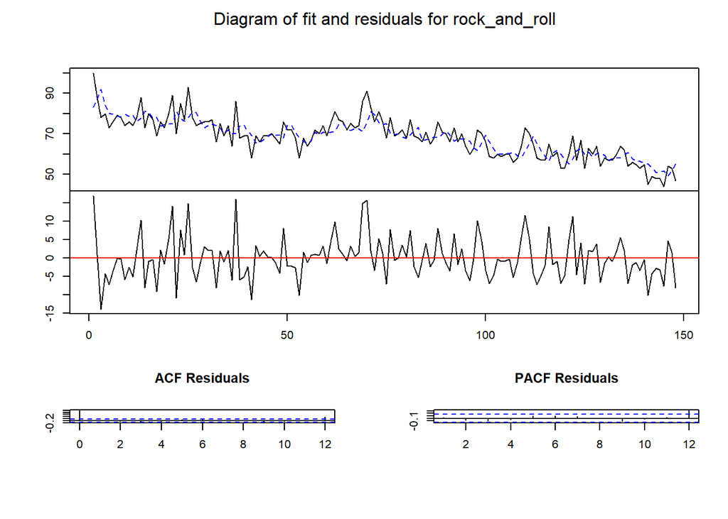

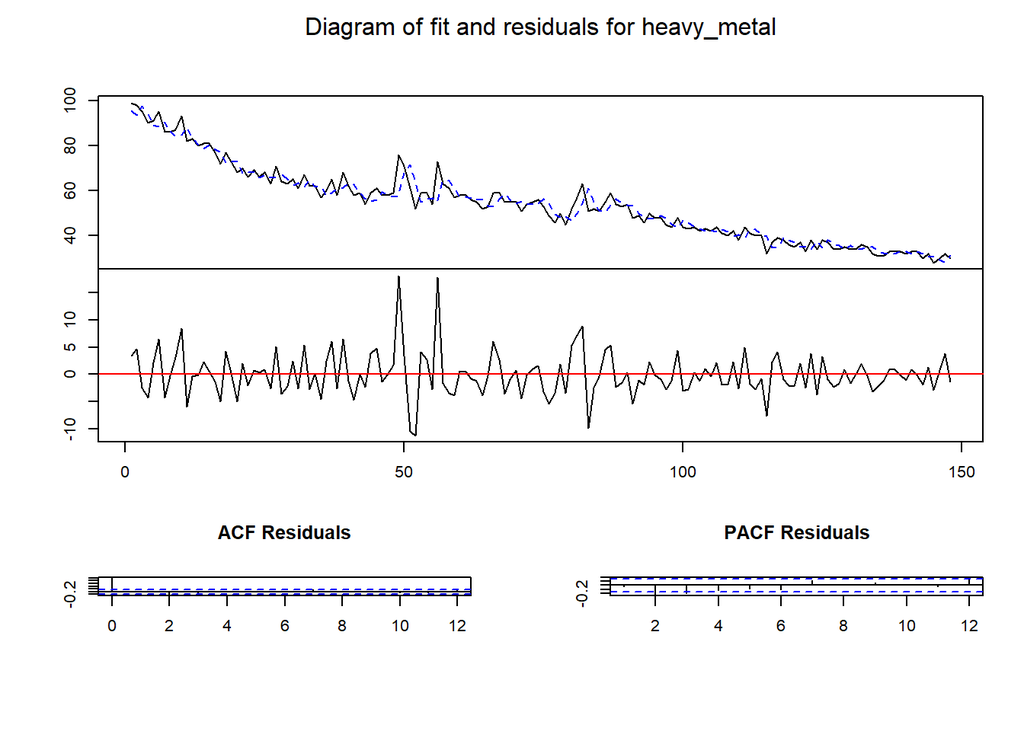

```r
windows(width=8, height=8)
plot(var_2)
```

6. **Impulse Response Function**

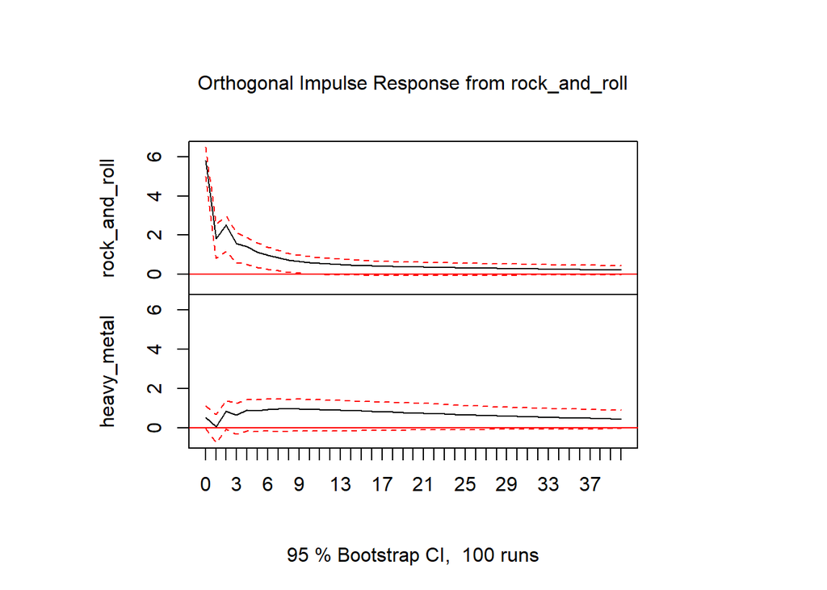

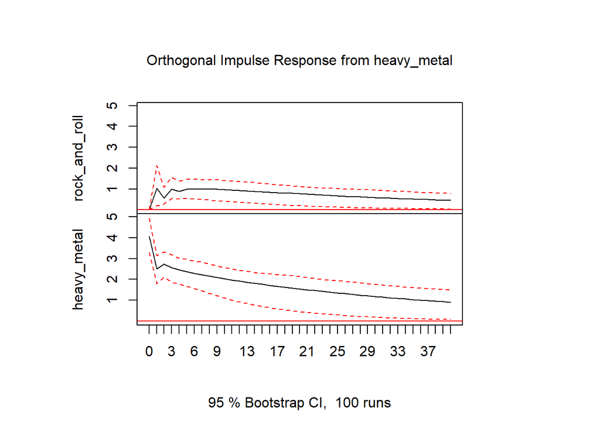

```r
plot(irf(var_2, n.ahead = 40))
```

As we can see that as time goes by, the effect of shock decays.

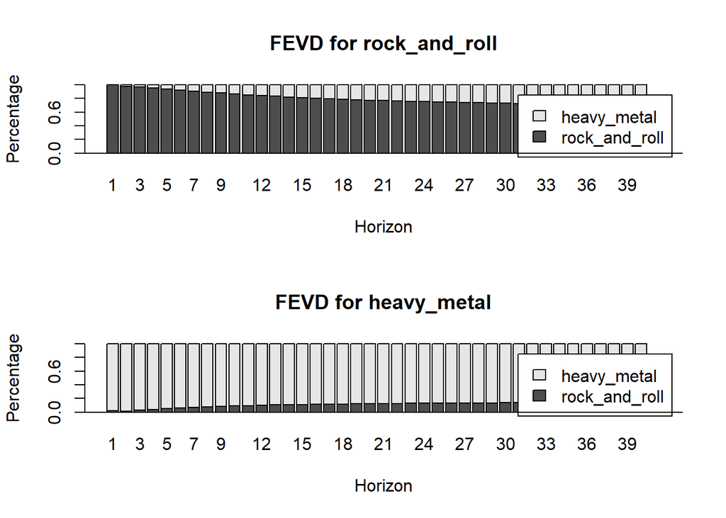

```r
plot(fevd(var_2, n.ahead = 40))
```

FEVD for “rock and roll” shows “rock and roll” has larger impact while FEVD for “heavy metal” shows “heavy metal” has larger impact.

7. **12-month periods ahead forecast with VAR(2,2)**

```r
tail(rock_and_roll_heavy_metal,14)
```

```
##            rock_and_roll heavy_metal
## 2015-05-01            62          31
## 2015-06-01            54          31
## 2015-07-01            56          33
## 2015-08-01            55          33
## 2015-09-01            53          33
## 2015-10-01            55          32
## 2015-11-01            45          33
## 2015-12-01            49          33
## 2016-01-01            48          30
## 2016-02-01            48          32
## 2016-03-01            44          28
## 2016-04-01            54          30
## 2016-05-01            53          32
## 2016-06-01            47          30
```

```r
rock_and_roll_heavy_metal.short <- rock_and_roll_heavy_metal["/2016-06-01",]
tail(rock_and_roll_heavy_metal.short)
```

```
##            rock_and_roll heavy_metal
## 2016-01-01            48          30
## 2016-02-01            48          32
## 2016-03-01            44          28
## 2016-04-01            54          30
## 2016-05-01            53          32
## 2016-06-01            47          30
```

```r
var2_short <- VAR (rock_and_roll_heavy_metal.short,p = 2,type=c("none"))
var2_short_forecast <- predict(var2_short,
                               n.ahead = 12,
                               ci= 0.95)
```

We need to extract data from “fcst” columns for both “rock and roll” and “heavy metal”.

```r
var2_short_forecast
```

```
## $rock_and_roll
##           fcst    lower    upper       CI
##  [1,] 48.80855 36.90499 60.71211 11.90356
##  [2,] 47.21476 34.03539 60.39413 13.17937
##  [3,] 47.08926 31.62168 62.55684 15.46758
##  [4,] 46.41547 29.57036 63.26057 16.84510
##  [5,] 45.97763 27.75675 64.19850 18.22088
##  [6,] 45.48873 26.11328 64.86418 19.37545
##  [7,] 45.03974 24.60591 65.47358 20.43383
##  [8,] 44.60478 23.21252 65.99704 21.39226
##  [9,] 44.18541 21.91088 66.45993 22.27453
## [10,] 43.78249 20.69001 66.87498 23.09248
## [11,] 43.39244 19.53681 67.24807 23.85563
## [12,] 43.01584 18.44366 67.58801 24.57217
##
## $heavy_metal
##           fcst    lower    upper        CI
##  [1,] 31.37448 23.34962 39.39935  8.024864
##  [2,] 30.80335 21.39232 40.21439  9.411034
##  [3,] 31.19520 20.26731 42.12310 10.927896
##  [4,] 31.08751 19.02218 43.15285 12.065336
##  [5,] 31.17745 18.12780 44.22710 13.049649
##  [6,] 31.15363 17.23741 45.06985 13.916221
##  [7,] 31.15219 16.46753 45.83685 14.684661
##  [8,] 31.11994 15.73530 46.50458 15.384640
##  [9,] 31.07932 15.05442 47.10422 16.024898
## [10,] 31.02420 14.40515 47.64325 16.619051
## [11,] 30.95810 13.78442 48.13178 17.173681
## [12,] 30.88156 13.18592 48.57721 17.695646
```

```r
var2_short_forecast$fcst$rock_and_roll
```

```
##           fcst    lower    upper       CI
##  [1,] 48.80855 36.90499 60.71211 11.90356
##  [2,] 47.21476 34.03539 60.39413 13.17937
##  [3,] 47.08926 31.62168 62.55684 15.46758
##  [4,] 46.41547 29.57036 63.26057 16.84510
##  [5,] 45.97763 27.75675 64.19850 18.22088
##  [6,] 45.48873 26.11328 64.86418 19.37545
##  [7,] 45.03974 24.60591 65.47358 20.43383
##  [8,] 44.60478 23.21252 65.99704 21.39226
##  [9,] 44.18541 21.91088 66.45993 22.27453
## [10,] 43.78249 20.69001 66.87498 23.09248
## [11,] 43.39244 19.53681 67.24807 23.85563
## [12,] 43.01584 18.44366 67.58801 24.57217
```

```r
var2_short_forecast$fcst$heavy_metal
```

```
##           fcst    lower    upper        CI
##  [1,] 31.37448 23.34962 39.39935  8.024864
##  [2,] 30.80335 21.39232 40.21439  9.411034
##  [3,] 31.19520 20.26731 42.12310 10.927896
##  [4,] 31.08751 19.02218 43.15285 12.065336
##  [5,] 31.17745 18.12780 44.22710 13.049649
##  [6,] 31.15363 17.23741 45.06985 13.916221
##  [7,] 31.15219 16.46753 45.83685 14.684661
##  [8,] 31.11994 15.73530 46.50458 15.384640
##  [9,] 31.07932 15.05442 47.10422 16.024898
## [10,] 31.02420 14.40515 47.64325 16.619051
## [11,] 30.95810 13.78442 48.13178 17.173681
## [12,] 30.88156 13.18592 48.57721 17.695646
```

```r
tail(index(rock_and_roll_heavy_metal),12)
```

```
##  [1] "2015-07-01 GMT" "2015-08-01 GMT" "2015-09-01 GMT" "2015-10-01 GMT"
##  [5] "2015-11-01 GMT" "2015-12-01 GMT" "2016-01-01 GMT" "2016-02-01 GMT"
##  [9] "2016-03-01 GMT" "2016-04-01 GMT" "2016-05-01 GMT" "2016-06-01 GMT"
```

Let’s then coerce predicted data into xts and rename each column for “rock and roll”.

```r
rock_and_roll_forecast <- xts(var2_short_forecast$fcst$rock_and_roll[,-4],
                  order.by = tail(index(rock_and_roll_heavy_metal),12))

colnames(rock_and_roll_forecast) <-c("rr_fore","rr_lower","rr_upper")
rock_and_roll_forecast
```

```
##             rr_fore rr_lower rr_upper
## 2015-07-01 48.80855 36.90499 60.71211
## 2015-08-01 47.21476 34.03539 60.39413
## 2015-09-01 47.08926 31.62168 62.55684
## 2015-10-01 46.41547 29.57036 63.26057
## 2015-11-01 45.97763 27.75675 64.19850
## 2015-12-01 45.48873 26.11328 64.86418
## 2016-01-01 45.03974 24.60591 65.47358
## 2016-02-01 44.60478 23.21252 65.99704
## 2016-03-01 44.18541 21.91088 66.45993
## 2016-04-01 43.78249 20.69001 66.87498
## 2016-05-01 43.39244 19.53681 67.24807
## 2016-06-01 43.01584 18.44366 67.58801
```

We then do perform the same logic to “heavy metal”.

```r
heavy_metal_forecast <- xts (var2_short_forecast$fcst$heavy_metal[,-4],
                 order.by = tail(index(rock_and_roll_heavy_metal),12))
colnames(heavy_metal_forecast) <-c("hm_fore","hm_lower","hm_upper")
heavy_metal_forecast
```

```
##             hm_fore hm_lower hm_upper
## 2015-07-01 31.37448 23.34962 39.39935
## 2015-08-01 30.80335 21.39232 40.21439
## 2015-09-01 31.19520 20.26731 42.12310
## 2015-10-01 31.08751 19.02218 43.15285
## 2015-11-01 31.17745 18.12780 44.22710
## 2015-12-01 31.15363 17.23741 45.06985
## 2016-01-01 31.15219 16.46753 45.83685
## 2016-02-01 31.11994 15.73530 46.50458
## 2016-03-01 31.07932 15.05442 47.10422
## 2016-04-01 31.02420 14.40515 47.64325
## 2016-05-01 30.95810 13.78442 48.13178
## 2016-06-01 30.88156 13.18592 48.57721
```

Finally, let’s merge them together with the original data.

```r
rr_hm_merged <- merge( rock_and_roll_heavy_metal,
                     rock_and_roll_forecast,
                     heavy_metal_forecast)
rr_hm_merged
```

```
##            rock_and_roll heavy_metal  rr_fore rr_lower rr_upper  hm_fore
## 2004-01-01            87         100       NA       NA       NA       NA
## 2004-02-01            75          96       NA       NA       NA       NA
## 2004-03-01           100          99       NA       NA       NA       NA
## 2004-04-01            88          98       NA       NA       NA       NA
## 2004-05-01            78          95       NA       NA       NA       NA
## 2004-06-01            80          90       NA       NA       NA       NA
## 2004-07-01            73          91       NA       NA       NA       NA
## 2004-08-01            76          95       NA       NA       NA       NA
## 2004-09-01            79          86       NA       NA       NA       NA
## 2004-10-01            78          86       NA       NA       NA       NA
##        ...
## 2015-09-01            53          33 47.08926 31.62168 62.55684 31.19520
## 2015-10-01            55          32 46.41547 29.57036 63.26057 31.08751
## 2015-11-01            45          33 45.97763 27.75675 64.19850 31.17745
## 2015-12-01            49          33 45.48873 26.11328 64.86418 31.15363
## 2016-01-01            48          30 45.03974 24.60591 65.47358 31.15219
## 2016-02-01            48          32 44.60478 23.21252 65.99704 31.11994
## 2016-03-01            44          28 44.18541 21.91088 66.45993 31.07932
## 2016-04-01            54          30 43.78249 20.69001 66.87498 31.02420
## 2016-05-01            53          32 43.39244 19.53681 67.24807 30.95810
## 2016-06-01            47          30 43.01584 18.44366 67.58801 30.88156
##            hm_lower hm_upper
## 2004-01-01       NA       NA
## 2004-02-01       NA       NA
## 2004-03-01       NA       NA
## 2004-04-01       NA       NA
## 2004-05-01       NA       NA
## 2004-06-01       NA       NA
## 2004-07-01       NA       NA
## 2004-08-01       NA       NA
## 2004-09-01       NA       NA
## 2004-10-01       NA       NA
##        ...
## 2015-09-01 20.26731 42.12310
## 2015-10-01 19.02218 43.15285
## 2015-11-01 18.12780 44.22710
## 2015-12-01 17.23741 45.06985
## 2016-01-01 16.46753 45.83685
## 2016-02-01 15.73530 46.50458
## 2016-03-01 15.05442 47.10422
## 2016-04-01 14.40515 47.64325
## 2016-05-01 13.78442 48.13178
## 2016-06-01 13.18592 48.57721
```

Let’s plot the result of forecasting for “rock and roll” first.

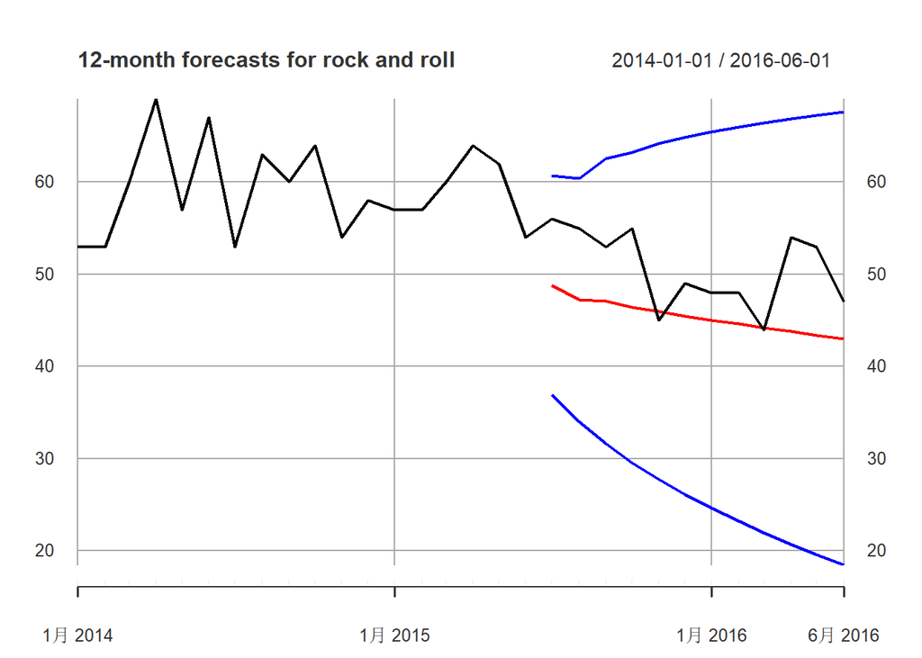

```r
plot(rr_hm_merged["2014/",c("rock_and_roll","rr_fore","rr_lower","rr_upper")],
     major.ticks="years",
     grid.ticks.on="years",
     grid.tick.lty=3,
     col=c("black","red","blue","blue"),
     main= "12-month forecasts for rock and roll")
```

Then plot the result of forecasting for “heavy metal”

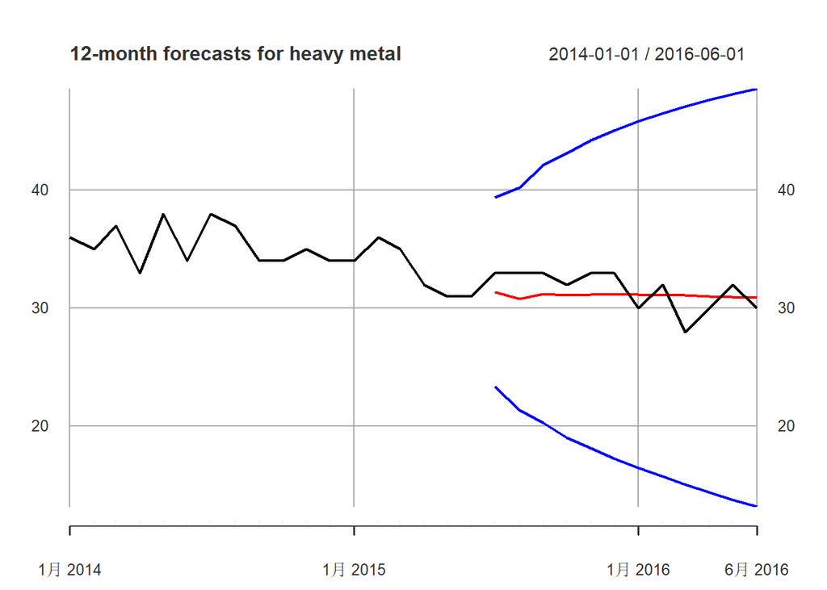

```r
plot(rr_hm_merged["2014/",c("heavy_metal","hm_fore","hm_lower","hm_upper")],
     major.ticks="years",
     grid.ticks.on="years",
     grid.tick.lty=3,
     col=c("black","red","blue","blue"),
     main= "12-month forecasts for heavy metal")
```

```r
rr_hm_merged$mae.rock_and_roll<-  abs(rr_hm_merged$rock_and_roll - rr_hm_merged$rr_fore)
rr_hm_merged$mse.rock_and_roll <-  (rr_hm_merged$rock_and_roll - rr_hm_merged$rr_fore) ^ 2
rr_hm_merged$mape.rock_and_roll<-  abs((rr_hm_merged$rock_and_roll - rr_hm_merged$rr_fore)/rr_hm_merged$rock_and_roll)
rr_hm_merged$amape.rock_and_roll <-  abs((rr_hm_merged$rock_and_roll - rr_hm_merged$rr_fore) /
                            (rr_hm_merged$rock_and_roll + rr_hm_merged$rr_fore))

rr_hm_merged$mae.heavy_metal<-  abs(rr_hm_merged$heavy_metal - rr_hm_merged$hm_fore)
rr_hm_merged$mse.heavy_metal <-  (rr_hm_merged$heavy_metal - rr_hm_merged$hm_fore) ^ 2
rr_hm_merged$mape.heavy_metal<-  abs((rr_hm_merged$heavy_metal - rr_hm_merged$hm_fore)/rr_hm_merged$heavy_metal)
rr_hm_merged$amape.heavy_metal<-  abs((rr_hm_merged$heavy_metal - rr_hm_merged$hm_fore) /
                                             (rr_hm_merged$heavy_metal + rr_hm_merged$hm_fore))

tail(rr_hm_merged,12)
```

```
##            rock_and_roll heavy_metal  rr_fore rr_lower rr_upper  hm_fore
## 2015-07-01            56          33 48.80855 36.90499 60.71211 31.37448
## 2015-08-01            55          33 47.21476 34.03539 60.39413 30.80335
## 2015-09-01            53          33 47.08926 31.62168 62.55684 31.19520
## 2015-10-01            55          32 46.41547 29.57036 63.26057 31.08751
## 2015-11-01            45          33 45.97763 27.75675 64.19850 31.17745
## 2015-12-01            49          33 45.48873 26.11328 64.86418 31.15363
## 2016-01-01            48          30 45.03974 24.60591 65.47358 31.15219
## 2016-02-01            48          32 44.60478 23.21252 65.99704 31.11994
## 2016-03-01            44          28 44.18541 21.91088 66.45993 31.07932
## 2016-04-01            54          30 43.78249 20.69001 66.87498 31.02420
## 2016-05-01            53          32 43.39244 19.53681 67.24807 30.95810
## 2016-06-01            47          30 43.01584 18.44366 67.58801 30.88156
##            hm_lower hm_upper mae.rock_and_roll mse.rock_and_roll
## 2015-07-01 23.34962 39.39935         7.1914539       51.71700955
## 2015-08-01 21.39232 40.21439         7.7852395       60.60995359
## 2015-09-01 20.26731 42.12310         5.9107400       34.93684716
## 2015-10-01 19.02218 43.15285         8.5845337       73.69421875
## 2015-11-01 18.12780 44.22710         0.9776253        0.95575126
## 2015-12-01 17.23741 45.06985         3.5112702       12.32901869
## 2016-01-01 16.46753 45.83685         2.9602553        8.76311148
## 2016-02-01 15.73530 46.50458         3.3952196       11.52751638
## 2016-03-01 15.05442 47.10422         0.1854053        0.03437513
## 2016-04-01 14.40515 47.64325        10.2175072      104.39745291
## 2016-05-01 13.78442 48.13178         9.6075611       92.30523019
## 2016-06-01 13.18592 48.57721         3.9841629       15.87355440
##            mape.rock_and_roll amape.rock_and_roll mae.heavy_metal
## 2015-07-01        0.128418820         0.068615148       1.6255166
## 2015-08-01        0.141549809         0.076165511       2.1966480
## 2015-09-01        0.111523396         0.059054688       1.8047964
## 2015-10-01        0.156082431         0.084647185       0.9124862
## 2015-11-01        0.021725007         0.010745777       1.8225519
## 2015-12-01        0.071658576         0.037160731       1.8463716
## 2016-01-01        0.061671986         0.031817105       1.1521918
## 2016-02-01        0.070733742         0.036663546       0.8800585
## 2016-03-01        0.004213757         0.002102449       3.0793193
## 2016-04-01        0.189213096         0.104492194       1.0242017
## 2016-05-01        0.181274738         0.099671315       1.0418977
## 2016-06-01        0.084769424         0.044260689       0.8815633
##            mse.heavy_metal mape.heavy_metal amape.heavy_metal
## 2015-07-01       2.6423041       0.04925808        0.02525095
## 2015-08-01       4.8252626       0.06656509        0.03442841
## 2015-09-01       3.2572901       0.05469080        0.02811419
## 2015-10-01       0.8326311       0.02851519        0.01446382
## 2015-11-01       3.3216956       0.05522885        0.02839864
## 2015-12-01       3.4090881       0.05595065        0.02878047
## 2016-01-01       1.3275460       0.03840639        0.01884138
## 2016-02-01       0.7745030       0.02750183        0.01394264
## 2016-03-01       9.4822073       0.10997569        0.05212178
## 2016-04-01       1.0489890       0.03414006        0.01678353
## 2016-05-01       1.0855508       0.03255930        0.01654906
## 2016-06-01       0.7771538       0.02938544        0.01447997
```

```r
dim(rr_hm_merged)
```

```
## [1] 150  16
```

```r
var2_error_measures_rock_and_roll <- colMeans(rr_hm_merged[,9:12],na.rm = TRUE)
var2_error_measures_rock_and_roll
```

```
##   mae.rock_and_roll   mse.rock_and_roll  mape.rock_and_roll amape.rock_and_roll
##          5.35924784         38.92866996          0.10190290          0.05461636
```

```r
var2_error_measures_heavy_metal <-colMeans(rr_hm_merged[,13:16],na.rm = TRUE)
var2_error_measures_heavy_metal
```

```
##   mae.heavy_metal   mse.heavy_metal  mape.heavy_metal amape.heavy_metal
##        1.52230025        2.73201846        0.04851478        0.02434624
```

For convenience, here we separate error measures of “rock and roll” and “heavy metal” for comparison with those produced by two ARIMA models later.

## 4.ARIMA models for “rock and roll”

1. **Let’s load data first and perform certain steps to extract important data we need for analysis.**

```r
rock_and_roll.2 <- gtrends(keyword =c("rock and roll"),
                      gprop = "web",
                      time= "2004-01-01 2016-06-01")

rock_and_roll.2$interest_over_time
```

| date | hits | keyword | geo | time | gprop | category |
| --- | --- | --- | --- | --- | --- | --- |
| 2004-01-01 | 87 | rock and roll | world | 2004-01-01 2016-06-01 | web | 0 |
| 2004-02-01 | 75 | rock and roll | world | 2004-01-01 2016-06-01 | web | 0 |
| 2004-03-01 | 100 | rock and roll | world | 2004-01-01 2016-06-01 | web | 0 |
| 2004-04-01 | 88 | rock and roll | world | 2004-01-01 2016-06-01 | web | 0 |
| 2004-05-01 | 78 | rock and roll | world | 2004-01-01 2016-06-01 | web | 0 |
| 2004-06-01 | 80 | rock and roll | world | 2004-01-01 2016-06-01 | web | 0 |
| 2004-07-01 | 73 | rock and roll | world | 2004-01-01 2016-06-01 | web | 0 |
| 2004-08-01 | 76 | rock and roll | world | 2004-01-01 2016-06-01 | web | 0 |
| 2004-09-01 | 79 | rock and roll | world | 2004-01-01 2016-06-01 | web | 0 |
| 2004-10-01 | 78 | rock and roll | world | 2004-01-01 2016-06-01 | web | 0 |

[output cut: 140 more lines]

```r
rock_and_roll.2<- rock_and_roll.2$interest_over_time[,1:2]
rock_and_roll.2 <-xts(rock_and_roll.2[,-1],order.by=rock_and_roll.2$date)
colnames(rock_and_roll.2) <- "rock_and_roll"
rock_and_roll.2
```

```
##            rock_and_roll
## 2004-01-01            87
## 2004-02-01            75
## 2004-03-01           100
## 2004-04-01            88
## 2004-05-01            78
## 2004-06-01            80
## 2004-07-01            73
## 2004-08-01            76
## 2004-09-01            79
## 2004-10-01            78
##        ...
## 2015-09-01            53
## 2015-10-01            55
## 2015-11-01            45
## 2015-12-01            49
## 2016-01-01            48
## 2016-02-01            48
## 2016-03-01            44
## 2016-04-01            54
## 2016-05-01            53
## 2016-06-01            47
```

2. **Let’s test stationarity and determine the order of integration (d)**

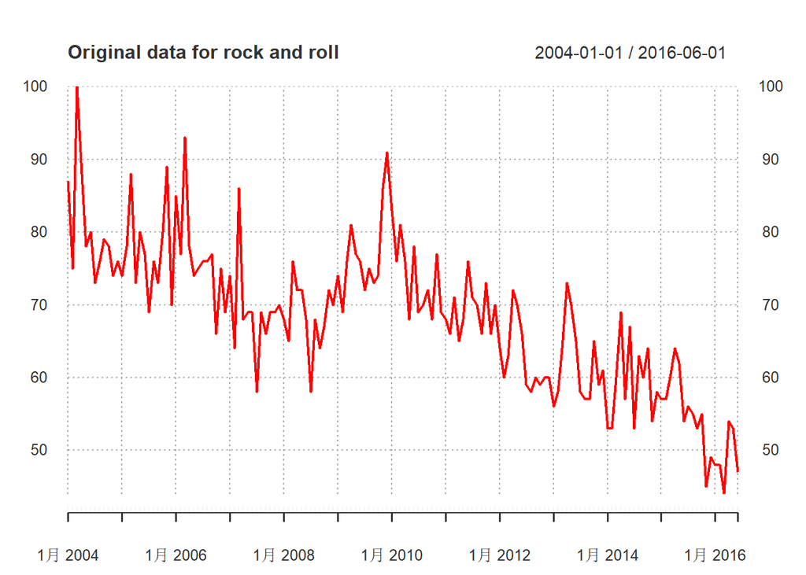

```r
plot(rock_and_roll.2,
     col="red",
    major.ticks="years",
   grid.ticks.on="years",
   grid.ticks.lty=3,
   main="Original data for rock and roll")
```

The gragh signifies very obvious non-stationarity, but we need to perform DF and ADF to confirm further instead of only passing judgement from the graph.

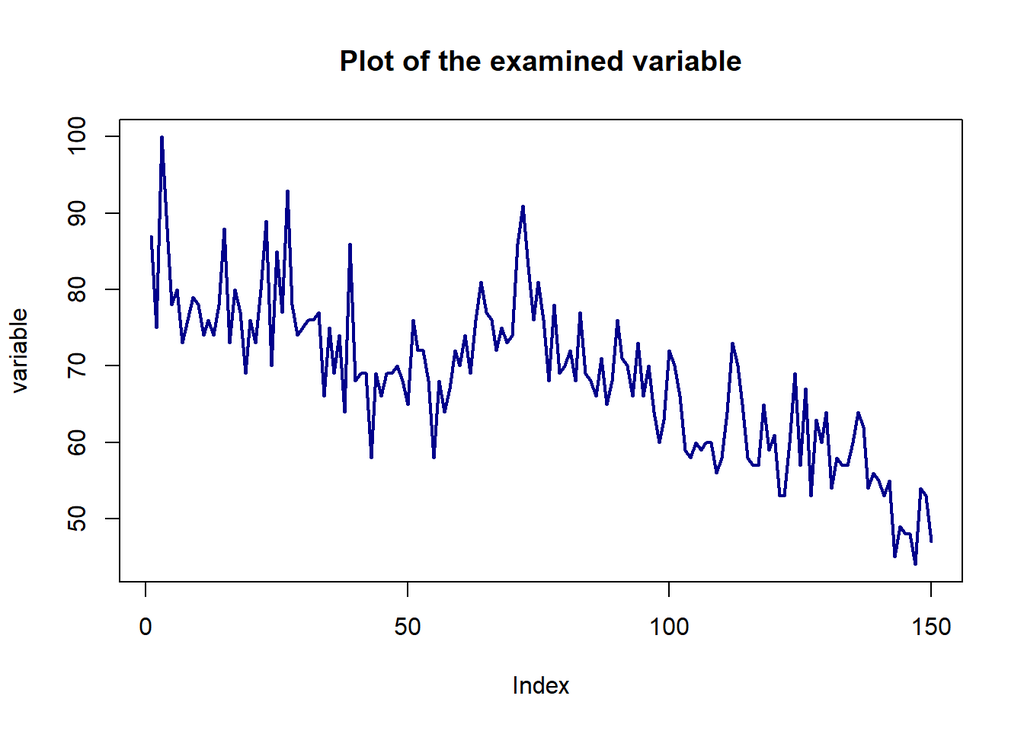

| augmentations | adf | p_adf | bgodfrey | p_bg |
| --- | --- | --- | --- | --- |
| 0 | -4.604732 | 0.0100000 | 16.01727536 | 6.276714e-05 |
| 1 | -2.385354 | 0.1709885 | 0.11985224 | 7.291948e-01 |
| 2 | -2.495574 | 0.1301046 | 0.11085463 | 7.391732e-01 |
| 3 | -2.211530 | 0.2354652 | 0.06035269 | 8.059394e-01 |
| 4 | -1.274671 | 0.5829757 | 0.18366521 | 6.682422e-01 |

```r
testdf(rock_and_roll.2$rock_and_roll,max.augmentations = 4)
```

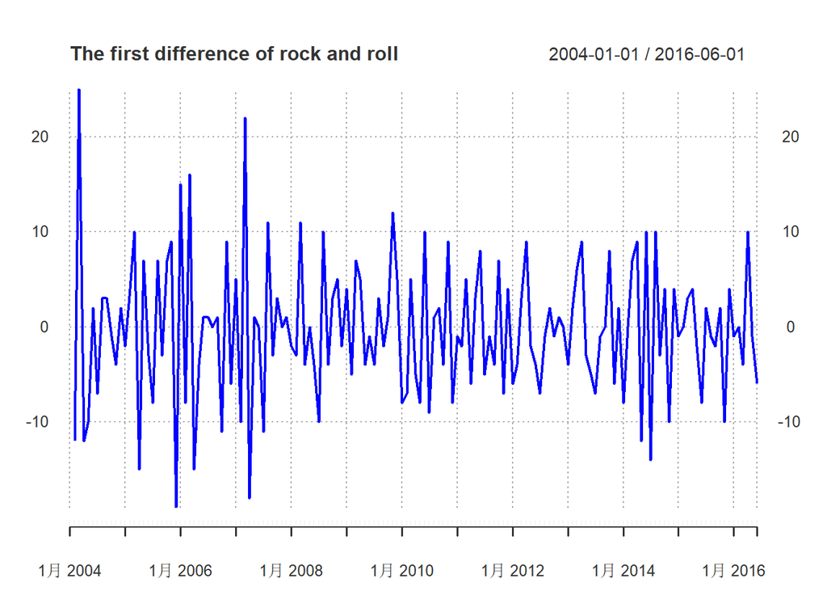

```r
rock_and_roll.2$diff <- diff(rock_and_roll.2$rock_and_roll)

plot(rock_and_roll.2$diff,
     col="blue",
     major.ticks="years",
     grid.ticks.on="years",
     grid.ticks.lty=3,
     main="The first difference of rock and roll")
```

The graph seems like white noise.

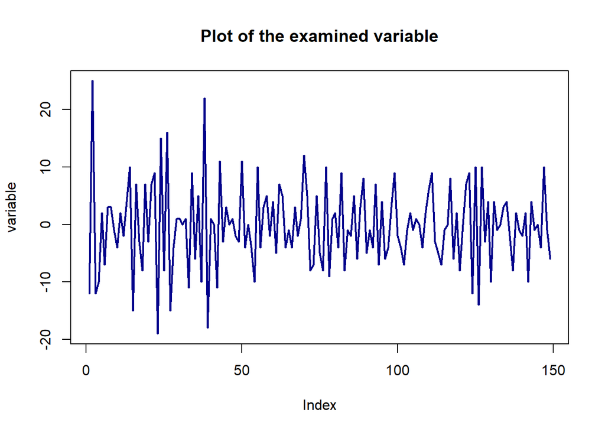

| augmentations | adf | p_adf | bgodfrey | p_bg |
| --- | --- | --- | --- | --- |
| 0 | -21.598021 | 0.01 | 0.398821321 | 0.5276986 |
| 1 | -12.458184 | 0.01 | 0.114253366 | 0.7353527 |
| 2 | -10.015488 | 0.01 | 0.220262050 | 0.6388403 |
| 3 | -9.948728 | 0.01 | 0.302018358 | 0.5826198 |
| 4 | -8.747865 | 0.01 | 0.004370936 | 0.9472878 |

```r
testdf(rock_and_roll.2$diff,max.augmentations = 4)
```

Based on ADF test, it is stationary, and there is no autocorrelation in its residuals according to BG test , so the order of integration is 1.

3. **In the next step, we should determine p and q**

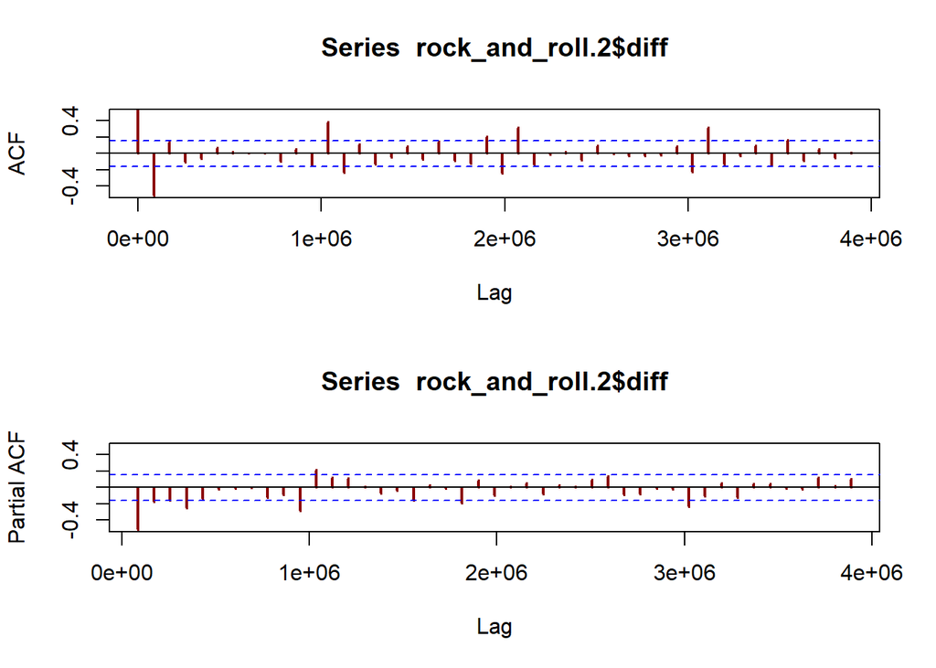

```r
par(mfrow = c(2, 1))
acf(rock_and_roll.2$diff,
    lag.max = 45,
    ylim = c(-0.5, 0.5),
    lwd = 2,
    col = "darkred",
    na.action = na.pass)
pacf(rock_and_roll.2$diff,
     lag.max = 45,
     ylim=c(-0.5,0.5),
     lwd = 2,
     col = "darkred",
     na.action = na.pass)
```

According to ACF and PACF graphs, many lags are significant. Let’s try ARIMA(1,1,1) first.

```r
arima_111 <- Arima(rock_and_roll.2$rock_and_roll,order=c(1,1,1),include.constant = TRUE)
```

4. **We then need to check parameters of ARIMA models**

```r
coeftest(arima_111)
```

```
##
## z test of coefficients:
##
##        Estimate Std. Error z value Pr(>|z|)
## ar1    0.040643   0.120545  0.3372  0.73600
## ma1   -0.763947   0.087506 -8.7302  < 2e-16 ***
## drift -0.235214   0.120395 -1.9537  0.05074 .
## ---
## Signif. codes:  0 '***' 0.001 '**' 0.01 '*' 0.05 '.' 0.1 ' ' 1
```

5. **Diagnostics: let’s check whether there is autocorrelation in the residuals**

plotting the residuals:

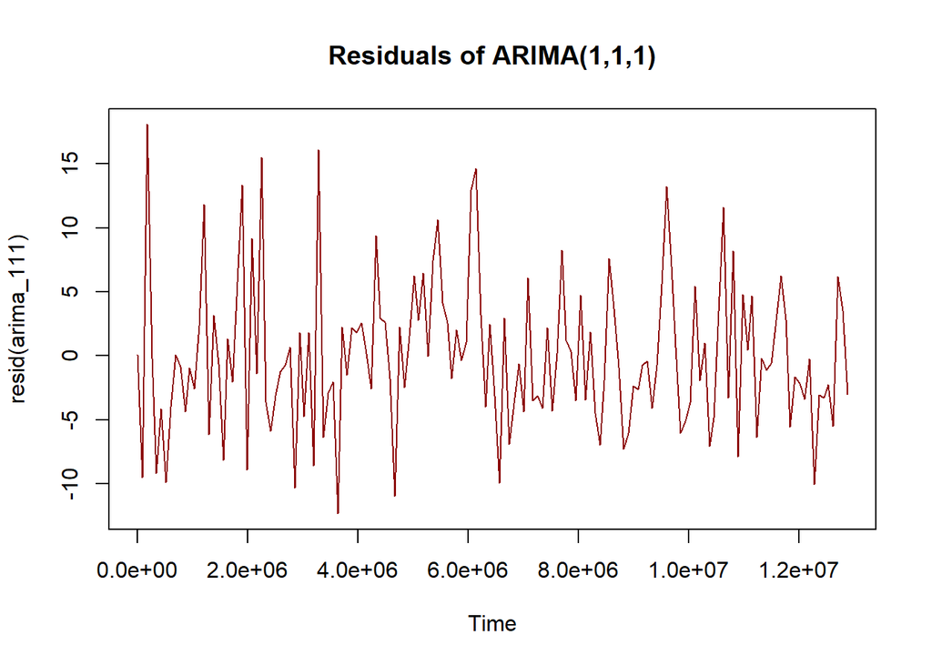

```r
plot(resid(arima_111),
     col="darkred",
  main="Residuals of ARIMA(1,1,1)") # The residuals look like white noise
```

ACF and PACF graphs for the residuals:

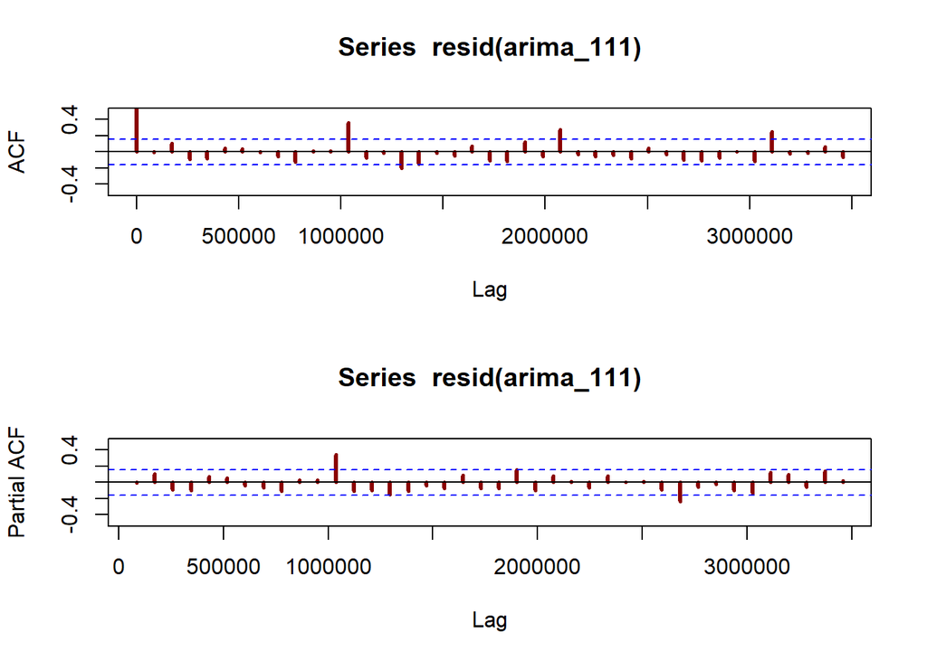

```r
par(mfrow = c(2, 1))
acf(resid(arima_111),
    lag.max = 40,
    ylim = c(-0.5, 0.5),
    lwd = 3, col = "darkred",
    na.action = na.pass)
pacf(resid(arima_111),
     lag.max =40,
     ylim = c(-0.5, 0.5),
     lwd =3, col = "darkred",
     na.action = na.pass)
```

Some lags are still significant and many are on the edge; however,plotting ACF and PACF is not formal way to test the existence of autocorrelation in the residuals.

Ljung-Box test as a formal way to check residuals:

```r
Box.test(resid(arima_111),type = c("Ljung-Box"),lag = 5)
```

```
##
##  Box-Ljung test
##
## data:  resid(arima_111)
## X-squared = 4.6498, df = 5, p-value = 0.4601
```

p-value is larger than 0.05, so we cannot reject the null hypothesis. There is no autocorrelation it its residuals. In conclusion, we could consider ARIMA(1,1,1).

6. **Let’s also try other models following the same steps shown above**
- ARIMA(1,1,2)

```r
arima_112<-Arima(rock_and_roll.2$rock_and_roll,order=c(1,1,2),include.constant = TRUE)
coeftest(arima_112)
```

```
##
## z test of coefficients:
##
##        Estimate Std. Error  z value  Pr(>|z|)
## ar1   -0.979540   0.031317 -31.2781 < 2.2e-16 ***
## ma1    0.226018   0.076069   2.9712  0.002966 **
## ma2   -0.691381   0.072792  -9.4980 < 2.2e-16 ***
## drift -0.237345   0.130506  -1.8186  0.068966 .
## ---
## Signif. codes:  0 '***' 0.001 '**' 0.01 '*' 0.05 '.' 0.1 ' ' 1
```

Let’s check residuals

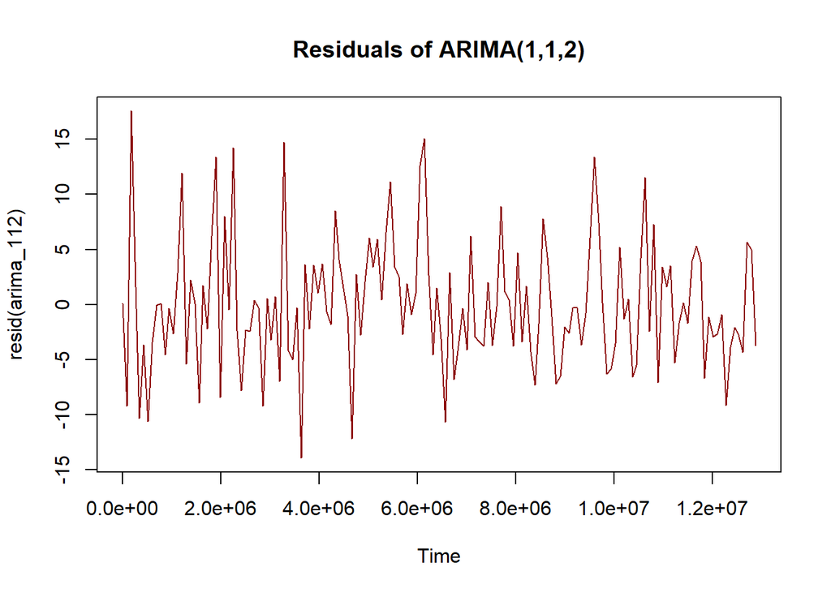

```r
plot(resid(arima_112),
     col="darkred",
  main="Residuals of ARIMA(1,1,2)")
```

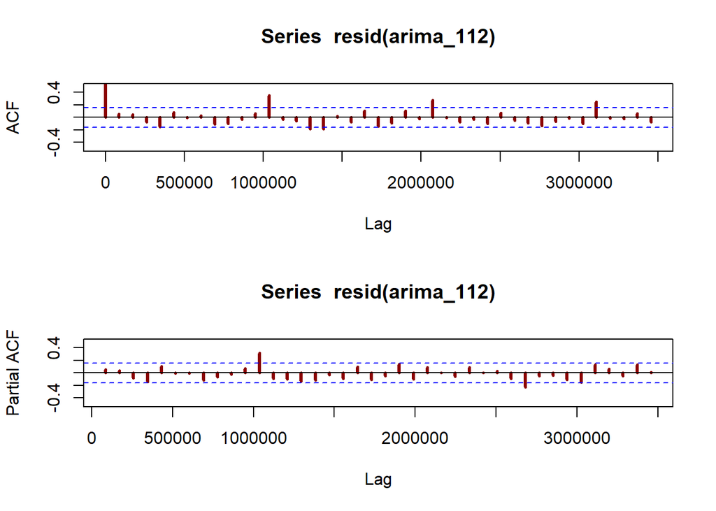

```r
par(mfrow = c(2, 1))
acf(resid(arima_112),
    lag.max = 40,
    ylim = c(-0.5, 0.5),
    lwd = 3, col = "darkred",
    na.action = na.pass)
pacf(resid(arima_112),
     lag.max =40,
     ylim = c(-0.5, 0.5),
     lwd =3, col = "darkred",
     na.action = na.pass)
```

```r
Box.test(resid(arima_112),type = c("Ljung-Box"),lag = 5)
```

```
##
##  Box-Ljung test
##
## data:  resid(arima_112)
## X-squared = 6.0505, df = 5, p-value = 0.3013
```

arima_112 could work

- ARIMA(1,1,5)

```r
arima_115<-Arima(rock_and_roll.2$rock_and_roll,order=c(1,1,5),include.constant = TRUE)
coeftest(arima_115)
```

```
##
## z test of coefficients:
##
##        Estimate Std. Error z value Pr(>|z|)
## ar1   -0.298461   0.465901 -0.6406  0.52178
## ma1   -0.422758   0.461653 -0.9157  0.35980
## ma2   -0.080816   0.329922 -0.2450  0.80649
## ma3   -0.210914   0.113866 -1.8523  0.06398 .
## ma4   -0.097365   0.144644 -0.6731  0.50086
## ma5    0.115058   0.093866  1.2258  0.22029
## drift -0.229060   0.112631 -2.0337  0.04198 *
## ---
## Signif. codes:  0 '***' 0.001 '**' 0.01 '*' 0.05 '.' 0.1 ' ' 1
```

Most parameters are insignificant

- ARIMA(3,1,4)

```r
arima_314<-Arima(rock_and_roll.2$rock_and_roll,order=c(3,1,4),include.constant = TRUE)
coeftest(arima_314)
```

```
##
## z test of coefficients:
##
##        Estimate Std. Error  z value  Pr(>|z|)
## ar1    0.404106   0.129169   3.1285  0.001757 **
## ar2   -0.255384   0.085228  -2.9965  0.002731 **
## ar3    0.665682   0.070325   9.4658 < 2.2e-16 ***
## ma1   -1.136444   0.129459  -8.7784 < 2.2e-16 ***
## ma2    0.743509   0.089170   8.3381 < 2.2e-16 ***
## ma3   -1.305814   0.080363 -16.2490 < 2.2e-16 ***
## ma4    0.698750   0.117051   5.9696 2.378e-09 ***
## drift -0.195455   0.037156  -5.2604 1.438e-07 ***
## ---
## Signif. codes:  0 '***' 0.001 '**' 0.01 '*' 0.05 '.' 0.1 ' ' 1
```

Then let’s diagnoize autocorrelation in its residuals.

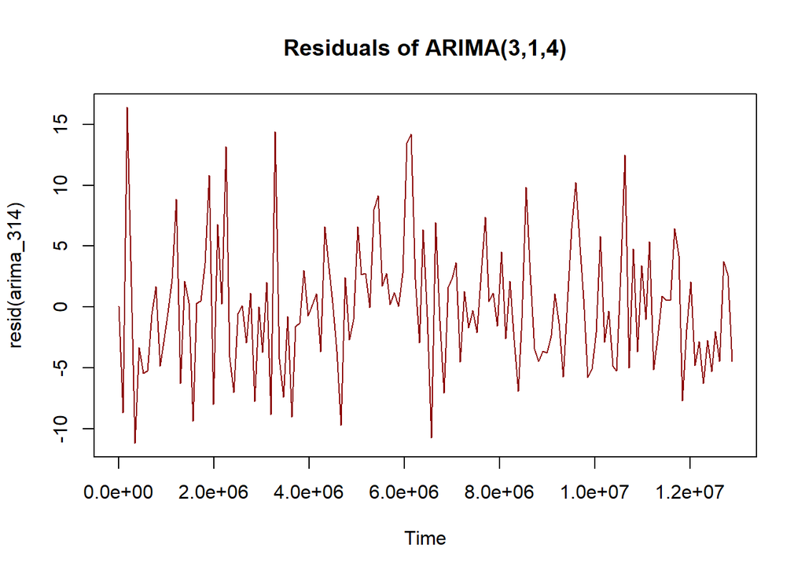

```r
plot(resid(arima_314),
     col="darkred",
     main="Residuals of ARIMA(3,1,4)",
)
```

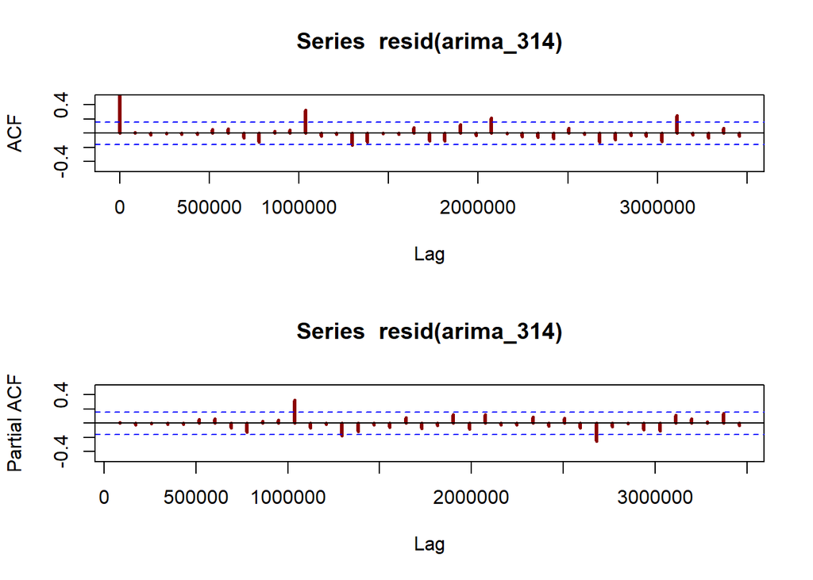

```r
par(mfrow = c(2, 1))
acf(resid(arima_314),
    lag.max = 40,
    ylim = c(-0.5, 0.5),
    lwd = 3, col = "darkred",
    na.action = na.pass)
pacf(resid(arima_314),
     lag.max =40,
     ylim = c(-0.5, 0.5),
     lwd =3, col = "darkred",
     na.action = na.pass)
```

```r
Box.test(resid(arima_314),type = c("Ljung-Box"),lag = 5)
```

```
##
##  Box-Ljung test
##
## data:  resid(arima_314)
## X-squared = 0.19827, df = 5, p-value = 0.9991
```

There is no autocorrelation in the residuals, so arima_314 could work.

- ARIMA(4,1,5)

```r
arima_415<-Arima(rock_and_roll.2$rock_and_roll,order=c(4,1,5))
coeftest(arima_415)
```

```
##
## z test of coefficients:
##
##     Estimate Std. Error z value Pr(>|z|)
## ar1  0.31632    1.12478  0.2812  0.77853
## ar2 -0.11452    0.53489 -0.2141  0.83047
## ar3  0.69689    0.27791  2.5076  0.01215 *
## ar4  0.10020    0.86526  0.1158  0.90780
## ma1 -0.99820    1.09687 -0.9100  0.36280
## ma2  0.51137    1.29050  0.3963  0.69192
## ma3 -1.17199    0.83436 -1.4047  0.16012
## ma4  0.49502    1.47417  0.3358  0.73703
## ma5  0.16658    0.83189  0.2002  0.84129
## ---
## Signif. codes:  0 '***' 0.001 '**' 0.01 '*' 0.05 '.' 0.1 ' ' 1
```

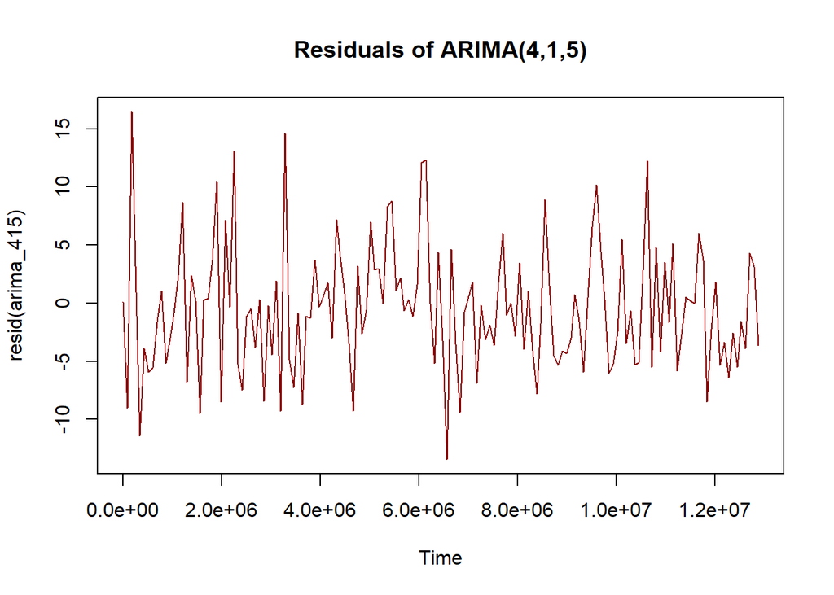

```r
plot(resid(arima_415),
     col="darkred",
     main="Residuals of ARIMA(4,1,5)")
```

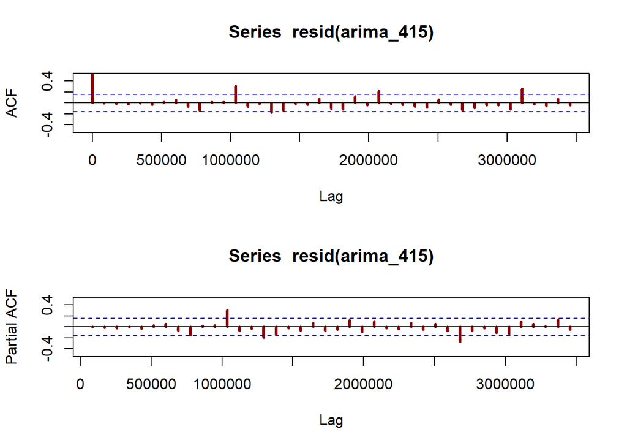

```r
par(mfrow = c(2, 1))
acf(resid(arima_415),
    lag.max = 40,
    ylim = c(-0.5, 0.5),
    lwd = 3, col = "darkred",
    na.action = na.pass)
pacf(resid(arima_415),
     lag.max =40,
     ylim = c(-0.5, 0.5),
     lwd =3, col = "darkred",
     na.action = na.pass)
```

```r
Box.test(resid(arima_415),type = c("Ljung-Box"),lag = 5)
```

```
##
##  Box-Ljung test
##
## data:  resid(arima_415)
## X-squared = 0.28323, df = 5, p-value = 0.9979
```

we can consider arima_415 as well.

- ARIMA(5,1,1)

```r
arima_511<-Arima(rock_and_roll.2$rock_and_roll,order=c(5,1,1),include.constant = FALSE)
coeftest(arima_511)
```

```
##
## z test of coefficients:
##
##       Estimate Std. Error z value Pr(>|z|)
## ar1  0.0050169  0.3569306  0.0141  0.98879
## ar2  0.1328517  0.2502375  0.5309  0.59549
## ar3 -0.1313332  0.1408384 -0.9325  0.35107
## ar4 -0.1223412  0.1576825 -0.7759  0.43783
## ar5  0.0924238  0.1608001  0.5748  0.56544
## ma1 -0.7026082  0.3432869 -2.0467  0.04069 *
## ---
## Signif. codes:  0 '***' 0.001 '**' 0.01 '*' 0.05 '.' 0.1 ' ' 1
```

Most parameters are insignificant.

Let’s use information criteria to make comparison

```r
AIC(arima_111, arima_415,arima_314,arima_112)
```

|  | df | AIC |
| --- | --- | --- |
| arima_111 | 4 | 957.1336 |
| arima_415 | 10 | 953.7523 |
| arima_314 | 9 | 946.8233 |
| arima_112 | 5 | 957.0617 |

```r
BIC(arima_111, arima_415,arima_314,arima_112)
```

|  | df | BIC |
| --- | --- | --- |
| arima_111 | 4 | 969.1494 |
| arima_415 | 10 | 983.7918 |
| arima_314 | 9 | 973.8588 |
| arima_112 | 5 | 972.0814 |

AIC suggests arima_314 while BIC suggests arima_111.

7. **Let’s perform 12-month ahead forecast by using arima_111 first**

We should upload data, extract data we need and merger the predicted data and the original data like what we did when using VAR(2,2).

```r
rock_and_roll.2
```

```
##            rock_and_roll diff
## 2004-01-01            87   NA
## 2004-02-01            75  -12
## 2004-03-01           100   25
## 2004-04-01            88  -12
## 2004-05-01            78  -10
## 2004-06-01            80    2
## 2004-07-01            73   -7
## 2004-08-01            76    3
## 2004-09-01            79    3
## 2004-10-01            78   -1
##        ...
## 2015-09-01            53   -2
## 2015-10-01            55    2
## 2015-11-01            45  -10
## 2015-12-01            49    4
## 2016-01-01            48   -1
## 2016-02-01            48    0
## 2016-03-01            44   -4
## 2016-04-01            54   10
## 2016-05-01            53   -1
## 2016-06-01            47   -6
```

```r
rock_and_roll.2<-rock_and_roll.2[,-2]
tail(rock_and_roll.2,13)
```

```
##            rock_and_roll
## 2015-06-01            54
## 2015-07-01            56
## 2015-08-01            55
## 2015-09-01            53
## 2015-10-01            55
## 2015-11-01            45
## 2015-12-01            49
## 2016-01-01            48
## 2016-02-01            48
## 2016-03-01            44
## 2016-04-01            54
## 2016-05-01            53
## 2016-06-01            47
```

```r
rock_and_roll.2.cut<- rock_and_roll.2["/2015-06-01",]
tail(rock_and_roll.2.cut)
```

```
##            rock_and_roll
## 2015-01-01            57
## 2015-02-01            57
## 2015-03-01            60
## 2015-04-01            64
## 2015-05-01            62
## 2015-06-01            54
```

```r
rr_arima_111 <- Arima(rock_and_roll.2.cut$rock_and_roll,
                        order=c(1,1,1),
                        include.constant = TRUE)

arima_111_forecast <- forecast(rr_arima_111,
                              h=12)
arima_111_forecast$mean
```

```
## Time Series:
## Start = 11923201
## End = 12873601
## Frequency = 1.15740740740741e-05
##  [1] 57.83701 57.83652 57.65830 57.47185 57.28502 57.09818 56.91133 56.72449
##  [9] 56.53764 56.35079 56.16395 55.97710
```

```r
arima_111_forecast$lower[,2]
```

```
## Time Series:
## Start = 11923201
## End = 12873601
## Frequency = 1.15740740740741e-05
##  [1] 46.07911 45.68166 45.21169 44.74408 44.28234 43.82628 43.37558 42.92992
##  [9] 42.48903 42.05266 41.62056 41.19253
```

```r
arima_111_forecast$upper[,2]
```

```
## Time Series:
## Start = 11923201
## End = 12873601
## Frequency = 1.15740740740741e-05
##  [1] 69.59492 69.99137 70.10491 70.19963 70.28771 70.37007 70.44708 70.51905
##  [9] 70.58624 70.64893 70.70733 70.76166
```

```r
forecast.data <- data.frame(mean=as.numeric(arima_111_forecast$mean),
                        lower=as.numeric(arima_111_forecast$lower[,2]),
                        upper=as.numeric(arima_111_forecast$upper[,2]))

forecast.data.xts <- xts(forecast.data,
                        order.by = tail(index(rock_and_roll.2),12))

rock_and_roll.2.2 <- merge(rock_and_roll.2,forecast.data.xts)
rock_and_roll.2.2
```

```
##            rock_and_roll     mean    lower    upper
## 2004-01-01            87       NA       NA       NA
## 2004-02-01            75       NA       NA       NA
## 2004-03-01           100       NA       NA       NA
## 2004-04-01            88       NA       NA       NA
## 2004-05-01            78       NA       NA       NA
## 2004-06-01            80       NA       NA       NA
## 2004-07-01            73       NA       NA       NA
## 2004-08-01            76       NA       NA       NA
## 2004-09-01            79       NA       NA       NA
## 2004-10-01            78       NA       NA       NA
##        ...
## 2015-09-01            53 57.65830 45.21169 70.10491
## 2015-10-01            55 57.47185 44.74408 70.19963
## 2015-11-01            45 57.28502 44.28234 70.28771
## 2015-12-01            49 57.09818 43.82628 70.37007
## 2016-01-01            48 56.91133 43.37558 70.44708
## 2016-02-01            48 56.72449 42.92992 70.51905
## 2016-03-01            44 56.53764 42.48903 70.58624
## 2016-04-01            54 56.35079 42.05266 70.64893
## 2016-05-01            53 56.16395 41.62056 70.70733
## 2016-06-01            47 55.97710 41.19253 70.76166
```

Let’s plot them together in a graph.

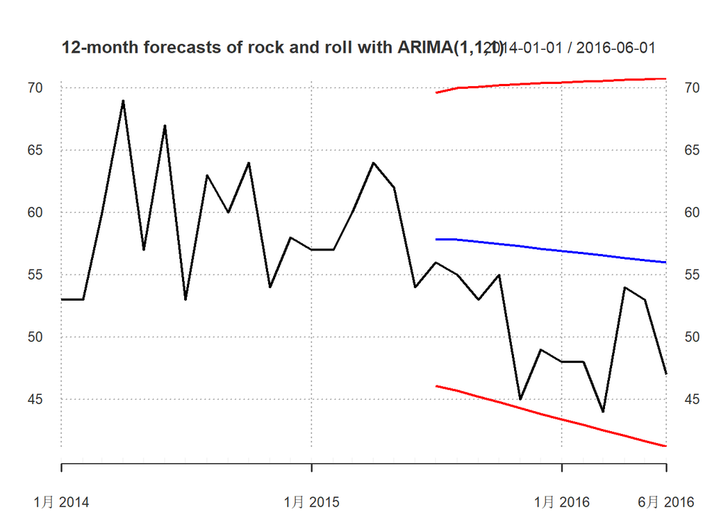

```r
plot(rock_and_roll.2.2["2014/",c("rock_and_roll","mean","lower","upper")],
     major.ticks = "years",
     grid.ticks.on = "years",
     grid.ticks.lty = 3,
     main = "12-month forecasts of rock and roll with ARIMA(1,1,1)",
     col = c("black", "blue", "red", "red"))
```

Finally let’s perform error measures.

```r
rock_and_roll.2.2$mae.rock_and_roll<-  abs(rock_and_roll.2.2$rock_and_roll - rock_and_roll.2.2$mean)
rock_and_roll.2.2$mse.rock_and_roll <-  (rock_and_roll.2.2$rock_and_roll - rock_and_roll.2.2$mean) ^ 2
rock_and_roll.2.2$mape.rock_and_roll<-  abs((rock_and_roll.2.2$rock_and_roll - rock_and_roll.2.2$mean)/rock_and_roll.2.2$rock_and_roll)
rock_and_roll.2.2$amape.rock_and_roll <-  abs((rock_and_roll.2.2$rock_and_roll - rock_and_roll.2.2$mean) /
                                             (rock_and_roll.2.2$rock_and_roll + rock_and_roll.2.2$mean))

dim(rock_and_roll.2.2)
```

```
## [1] 150   8
```

```r
error.arima111<- colMeans(rock_and_roll.2.2[,5:8],na.rm = TRUE)
error.arima111
```

```
##   mae.rock_and_roll   mse.rock_and_roll  mape.rock_and_roll amape.rock_and_roll
##          6.40434827         55.38154403          0.13350610          0.06101673
```

8. **Let’s also perform 12-month ahead forecast by using arima_314.2**

```r
rock_and_roll.2
```

```
##            rock_and_roll
## 2004-01-01            87
## 2004-02-01            75
## 2004-03-01           100
## 2004-04-01            88
## 2004-05-01            78
## 2004-06-01            80
## 2004-07-01            73
## 2004-08-01            76
## 2004-09-01            79
## 2004-10-01            78
##        ...
## 2015-09-01            53
## 2015-10-01            55
## 2015-11-01            45
## 2015-12-01            49
## 2016-01-01            48
## 2016-02-01            48
## 2016-03-01            44
## 2016-04-01            54
## 2016-05-01            53
## 2016-06-01            47
```

```r
tail(rock_and_roll.2,13)
```

```
##            rock_and_roll
## 2015-06-01            54
## 2015-07-01            56
## 2015-08-01            55
## 2015-09-01            53
## 2015-10-01            55
## 2015-11-01            45
## 2015-12-01            49
## 2016-01-01            48
## 2016-02-01            48
## 2016-03-01            44
## 2016-04-01            54
## 2016-05-01            53
## 2016-06-01            47
```

```r
rock_and_roll.2.cut<- rock_and_roll.2["/2015-06-01",]
tail(rock_and_roll.2.cut)
```

```
##            rock_and_roll
## 2015-01-01            57
## 2015-02-01            57
## 2015-03-01            60
## 2015-04-01            64
## 2015-05-01            62
## 2015-06-01            54
```

```r
rr_arima_314 <- Arima(rock_and_roll.2.cut$rock_and_roll,
                      order=c(3,1,4),
                      include.constant = TRUE)

rr_arima_314_forecast <- forecast(rr_arima_314,
                               h=12)
rr_arima_314_forecast$mean
```

```
## Time Series:
## Start = 11923201
## End = 12873601
## Frequency = 1.15740740740741e-05
##  [1] 58.52453 54.38171 59.06176 59.48921 55.63696 56.95514 58.80205 56.64894
##  [9] 56.08044 57.61018 56.95532 55.85869
```

```r
rr_arima_314_forecast$lower[,2]
```

```
## Time Series:
## Start = 11923201
## End = 12873601
## Frequency = 1.15740740740741e-05
##  [1] 47.49085 43.00635 46.74677 47.15631 43.27533 44.16338 45.90872 43.75139
##  [9] 43.04359 44.45140 43.78829 42.65398
```

```r
rr_arima_314_forecast$upper[,2]
```

```
## Time Series:
## Start = 11923201
## End = 12873601
## Frequency = 1.15740740740741e-05
##  [1] 69.55822 65.75708 71.37674 71.82211 67.99859 69.74691 71.69539 69.54649
##  [9] 69.11729 70.76897 70.12236 69.06341
```

```r
forecast.data.2 <- data.frame(mean=as.numeric(rr_arima_314_forecast$mean),
                            lower=as.numeric(rr_arima_314_forecast$lower[,2]),
                            upper=as.numeric(rr_arima_314_forecast$upper[,2]))

forecast.data.2.xts <- xts(forecast.data.2,
                         order.by = tail(index(rock_and_roll.2),12))

rock_and_roll.2.3 <- merge(rock_and_roll.2,forecast.data.2.xts)
```

let’s plot them together in a graph.

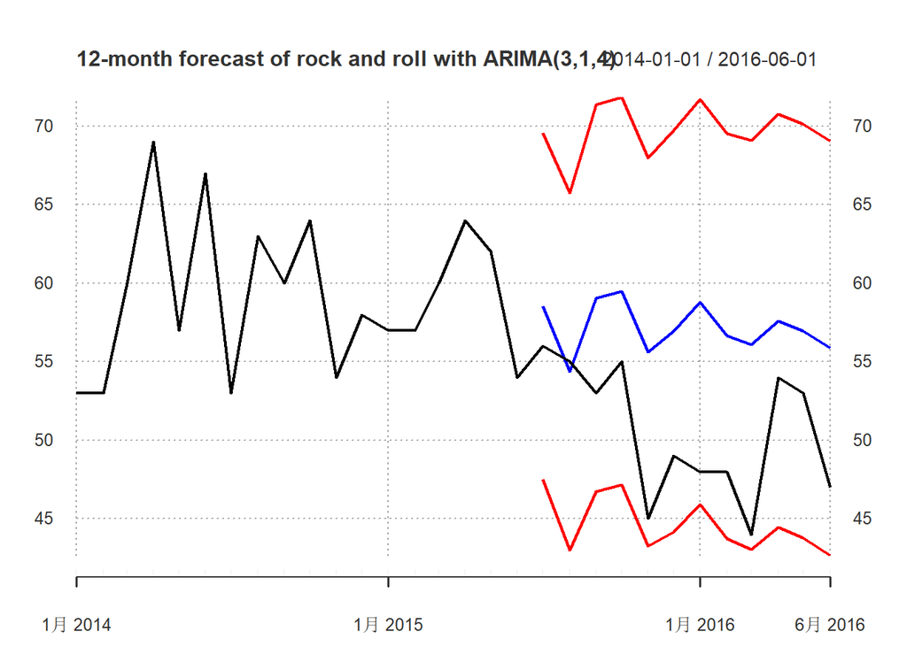

```r
plot(rock_and_roll.2.3["2014/",c("rock_and_roll","mean","lower","upper")],
     major.ticks = "years",
     grid.ticks.on = "years",
     grid.ticks.lty = 3,
     main = "12-month forecast of rock and roll with ARIMA(3,1,4)",
     col = c("black", "blue", "red", "red"))
```

Let’s perform error measures

```r
rock_and_roll.2.3$mae.rock_and_roll<-  abs(rock_and_roll.2.3$rock_and_roll - rock_and_roll.2.3$mean)
rock_and_roll.2.3$mse.rock_and_roll <-  (rock_and_roll.2.3$rock_and_roll - rock_and_roll.2.3$mean) ^ 2
rock_and_roll.2.3$mape.rock_and_roll<-  abs((rock_and_roll.2.3$rock_and_roll - rock_and_roll.2.3$mean)/rock_and_roll.2.3$rock_and_roll)
rock_and_roll.2.3$amape.rock_and_roll <-  abs((rock_and_roll.2.3$rock_and_roll - rock_and_roll.2.3$mean) /
                                                (rock_and_roll.2.3$rock_and_roll + rock_and_roll.2.3$mean))

dim(rock_and_roll.2.3)
```

```
## [1] 150   8
```

```r
error.arima314<- colMeans(rock_and_roll.2.3[,5:8],na.rm = TRUE)
error.arima314
```

```
##   mae.rock_and_roll   mse.rock_and_roll  mape.rock_and_roll amape.rock_and_roll
##          6.68679399         57.05523199          0.13839962          0.06339294
```

9. **Let’s compare arima_111 with arima_314**

```r
error.arima111
```

```
##   mae.rock_and_roll   mse.rock_and_roll  mape.rock_and_roll amape.rock_and_roll
##          6.40434827         55.38154403          0.13350610          0.06101673
```

```r
error.arima314
```

```
##   mae.rock_and_roll   mse.rock_and_roll  mape.rock_and_roll amape.rock_and_roll
##          6.68679399         57.05523199          0.13839962          0.06339294
```

```r
rbind(error.arima111,error.arima314)
```

```
##                mae.rock_and_roll mse.rock_and_roll mape.rock_and_roll
## error.arima111          6.404348          55.38154          0.1335061
## error.arima314          6.686794          57.05523          0.1383996
##                amape.rock_and_roll
## error.arima111          0.06101673
## error.arima314          0.06339294
```

arima_111 can produce a little bit more accurate forecasts than arima_314. So let’s use arima111

## 5.ARIMA models for heavy metal

1. **Let’s upload data first.**

```r
heavy_metal.2 <- gtrends(keyword = c("heavy metal"),
                   gprop = "web",
                   time= "2004-01-01 2016-06-01")
heavy_metal.2$interest_over_time
```

| date | hits | keyword | geo | time | gprop | category |
| --- | --- | --- | --- | --- | --- | --- |
| 2004-01-01 | 100 | heavy metal | world | 2004-01-01 2016-06-01 | web | 0 |
| 2004-02-01 | 96 | heavy metal | world | 2004-01-01 2016-06-01 | web | 0 |
| 2004-03-01 | 99 | heavy metal | world | 2004-01-01 2016-06-01 | web | 0 |
| 2004-04-01 | 98 | heavy metal | world | 2004-01-01 2016-06-01 | web | 0 |
| 2004-05-01 | 95 | heavy metal | world | 2004-01-01 2016-06-01 | web | 0 |
| 2004-06-01 | 90 | heavy metal | world | 2004-01-01 2016-06-01 | web | 0 |
| 2004-07-01 | 91 | heavy metal | world | 2004-01-01 2016-06-01 | web | 0 |
| 2004-08-01 | 95 | heavy metal | world | 2004-01-01 2016-06-01 | web | 0 |
| 2004-09-01 | 86 | heavy metal | world | 2004-01-01 2016-06-01 | web | 0 |
| 2004-10-01 | 86 | heavy metal | world | 2004-01-01 2016-06-01 | web | 0 |

[output cut: 140 more lines]

```r
heavy_metal.2<- heavy_metal.2$interest_over_time[,1:2]
heavy_metal.2 <-xts(heavy_metal.2[,-1],order.by=heavy_metal.2$date)
colnames(heavy_metal.2) <- "heavy_metal"
```

2. **Second, let’s test stationarity and determine d**

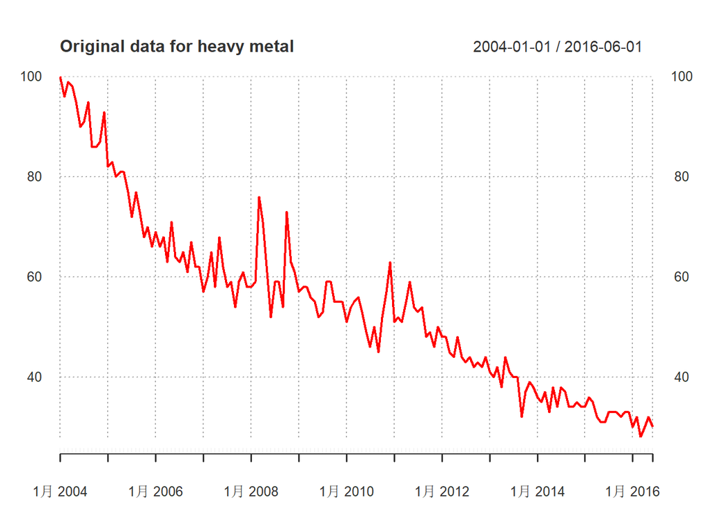

```r
plot(heavy_metal.2,
     col="red",
     major.ticks="years",
     grid.ticks.on="years",
     grid.ticks.lty=3,
     main="Original data for heavy metal")
```

The graph shows very obvious non-staionarity. Let’s also perform df test and its alternatives.

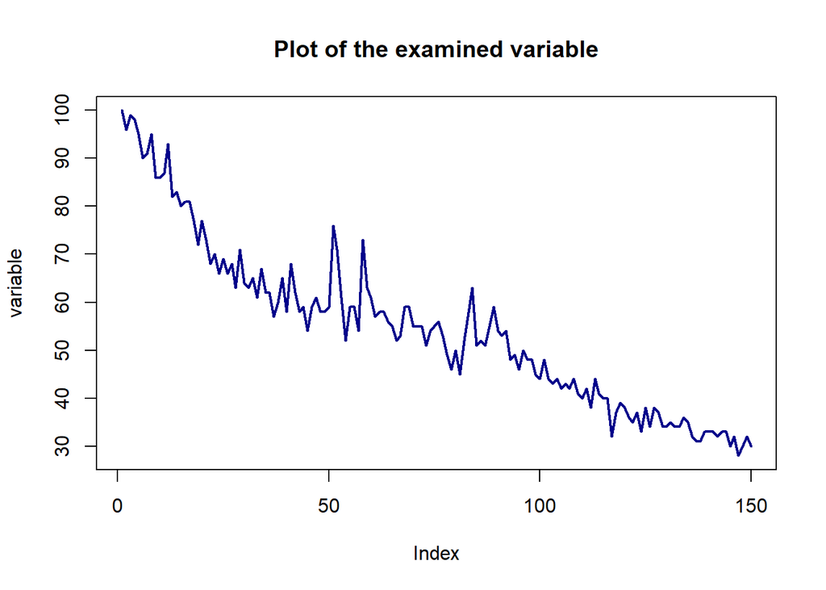

| augmentations | adf | p_adf | bgodfrey | p_bg |
| --- | --- | --- | --- | --- |
| 0 | -2.367901 | 0.17746259 | 17.56111263 | 2.782201e-05 |
| 1 | -2.090860 | 0.28022554 | 0.71144159 | 3.989657e-01 |
| 2 | -2.279728 | 0.21016875 | 0.36990234 | 5.430575e-01 |
| 3 | -2.478616 | 0.13639485 | 0.43856114 | 5.078178e-01 |
| 4 | -2.669799 | 0.08498942 | 0.05195995 | 8.196873e-01 |
| 5 | -2.497976 | 0.12921367 | 0.04806910 | 8.264579e-01 |

```r
testdf(heavy_metal.2$heavy_metal,max.augmentations = 5)
```